# index

## Phase 1: Creating Master Data

1. List down global market indices:
   1. Nifty 50
   2. Dow Jones Index
   3. Nasdaq
   4. Hang Seng
   5. Nikkei 225
   6. DAX
2. Check symbols for each of the indices above which will help you to fetch data
3. Check R/Python syntax to download data for each index for six years (from 1st Jan 2018 till 31st Dec 2023 – OHLC Data)
4. Add USA VIX data for six years (Volatility Index – Fear Factor)
5. Calculate daily returns based on close prices of each index: (Y<sub>t</sub> – Y<sub>t–1</sub>) / Y<sub>t–1</sub> × 100
6. Check if daily returns follow a normal distribution
7. Rename variables in each file (e.g., Nifty50_Open, Nifty50_Adjclose)
8. Merge all the above files with outer join (note that holidays differ globally)
9. Impute missing data using the LOCF method
10. Create indicator variable for “Quarter”
11. Create indicator variable for “Month”
12. Create indicator variable for “Year”
13. Finalize Master Data which will be used for Phase 2

### ________________________________________________________________________________________________________________________________________________________________________________________

```python
# %%
import yfinance as yf
import pandas as pd
import numpy as np
from tabulate import tabulate
import seaborn as sns
import matplotlib.pyplot as plt
import scipy.stats as stats
from scipy.stats import shapiro
import os

# Define tickers and friendly names
tickers = {
    "^NSEI": "Nifty",
    "^DJI": "DowJones",
    "^IXIC": "Nasdaq",
    "^HSI": "HangSeng",
    "^N225": "Nikkei",
    "^GDAXI": "DAX",
    "^VIX": "VIX",
}

start_date = "2018-11-01"
end_date = "2025-02-28"

# Download and keep only Open and Close
data_frames = {}
for ticker, name in tickers.items():
    data = yf.download(ticker, start=start_date, end=end_date)[['Open', 'Close']]
    data.columns = [f"{name}_Open", f"{name}_Close"]
    data_frames[name] = data

# Get full date range including all days (weekends and holidays included)
full_range = pd.date_range(start=start_date, end=end_date, freq='D')

# Remove weekends before interpolation
full_range = full_range[full_range.dayofweek < 5]

# Remove 1st of January of each year as this is a holiday in many markets
full_range = full_range[~((full_range.month == 1) & (full_range.day == 1))]


# Reindex each DataFrame and interpolate OPen and Close using both Open and Close info
for name, df in data_frames.items():
    df.index = pd.to_datetime(df.index)
    df = df.sort_index()
    df = df.reindex(full_range)

    open_col = f"{name}_Open"
    close_col = f"{name}_Close"

    # Interpolate Open and Close individually
    interpolated_open = df[open_col].interpolate(method='linear', limit_direction='both')
    interpolated_close = df[close_col].interpolate(method='linear', limit_direction='both')

    # Fill NaNs only, preserving original non-NaN values
    df[open_col] = df[open_col].combine_first(interpolated_open)
    df[close_col] = df[close_col].combine_first(interpolated_close)

    data_frames[name] = df

# Merge all into one master table
master_table = pd.concat(data_frames.values(), axis=1)


# Calculate daily returns (exclude VIX)
returns = pd.DataFrame(index=master_table.index)
for name in tickers.values():
    close_col = f"{name}_Close"
    if close_col in master_table.columns:
        return_col = f"{name}_Return"
        returns[return_col] = master_table[close_col].pct_change() * 100

# Merge returns into master_table
master_table = pd.concat([master_table, returns], axis=1)

# Add Year, Quarter, Month as new columns
master_table['Year'] = master_table.index.year
master_table['Quarter'] = master_table.index.quarter
master_table['Month'] = master_table.index.month


master_table = master_table[(master_table['Year'] >= 2019) & (master_table['Year'] <= 2024)]

# print master table head
from IPython.display import display
display(master_table.head(20))
```

```
[*********************100%***********************]  1 of 1 completed
```

```
[*********************100%***********************]  1 of 1 completed
[*********************100%***********************]  1 of 1 completed
[*********************100%***********************]  1 of 1 completed
[*********************100%***********************]  1 of 1 completed
[*********************100%***********************]  1 of 1 completed
[*********************100%***********************]  1 of 1 completed
```

|  | Nifty_Open | Nifty_Close | DowJones_Open | DowJones_Close | Nasdaq_Open | Nasdaq_Close | HangSeng_Open | HangSeng_Close | Nikkei_Open | Nikkei_Close | ... | Nifty_Return | DowJones_Return | Nasdaq_Return | HangSeng_Return | Nikkei_Return | DAX_Return | VIX_Return | Year | Quarter | Month |
| --- | --- | --- | --- | --- | --- | --- | --- | --- | --- | --- | --- | --- | --- | --- | --- | --- | --- | --- | --- | --- | --- |
| 2019-01-02 | 10868.849609 | 10792.500000 | 23058.609375 | 23346.240234 | 6506.910156 | 6665.939941 | 25824.439453 | 25130.349609 | 19806.505859 | 19788.365234 | ... | -0.644874 | 0.080503 | 0.462078 | -2.767770 | -0.568810 | 0.100432 | -8.654606 | 2019 | 1 | 1 |
| 2019-01-03 | 10796.799805 | 10672.250000 | 23176.390625 | 22686.220703 | 6584.770020 | 6463.500000 | 25077.679688 | 25064.359375 | 19730.818359 | 19675.163086 | ... | -1.114200 | -2.827091 | -3.036930 | -0.262592 | -0.572064 | -1.545627 | 9.603796 | 2019 | 1 | 1 |
| 2019-01-04 | 10699.700195 | 10727.349609 | 22894.919922 | 23433.160156 | 6567.140137 | 6738.859863 | 24946.119141 | 25626.029297 | 19655.130859 | 19561.960938 | ... | 0.516289 | 3.292481 | 4.260228 | 2.240911 | -0.575356 | 3.369893 | -15.992147 | 2019 | 1 | 1 |
| 2019-01-07 | 10804.849609 | 10771.799805 | 23474.259766 | 23531.349609 | 6757.529785 | 6823.470215 | 26015.839844 | 25835.699219 | 19944.609375 | 20038.970703 | ... | 0.414363 | 0.419019 | 1.255559 | 0.818191 | 2.438456 | -0.184634 | 0.093548 | 2019 | 1 | 1 |
| 2019-01-08 | 10786.250000 | 10802.150391 | 23680.320312 | 23787.449219 | 6893.439941 | 6897.000000 | 25852.500000 | 25875.449219 | 20224.669922 | 20204.039062 | ... | 0.281760 | 1.088334 | 1.077601 | 0.153857 | 0.823737 | 0.522626 | -4.345796 | 2019 | 1 | 1 |
| 2019-01-09 | 10862.400391 | 10855.150391 | 23844.269531 | 23879.119141 | 6923.060059 | 6957.080078 | 26237.289062 | 26462.320312 | 20366.300781 | 20427.060547 | ... | 0.490643 | 0.385371 | 0.871105 | 2.268061 | 1.103846 | 0.826916 | -2.393746 | 2019 | 1 | 1 |
| 2019-01-10 | 10859.349609 | 10821.599609 | 23811.109375 | 24001.919922 | 6908.649902 | 6986.069824 | 26391.779297 | 26521.429688 | 20270.880859 | 20163.800781 | ... | -0.309077 | 0.514260 | 0.416694 | 0.223372 | -1.288779 | 0.259513 | -2.402400 | 2019 | 1 | 1 |
| 2019-01-11 | 10834.750000 | 10794.950195 | 23940.009766 | 23995.949219 | 6947.459961 | 6971.479980 | 26692.019531 | 26667.269531 | 20296.449219 | 20359.699219 | ... | -0.246261 | -0.024876 | -0.208842 | 0.549894 | 0.971535 | -0.312499 | -6.717946 | 2019 | 1 | 1 |
| 2019-01-14 | 10807.000000 | 10737.599609 | 23880.529297 | 23909.839844 | 6908.029785 | 6905.919922 | 26559.679688 | 26298.330078 | 20280.634766 | 20457.494141 | ... | -0.531272 | -0.358850 | -0.940404 | -1.383492 | 0.480336 | -0.289781 | 4.837818 | 2019 | 1 | 1 |
| 2019-01-15 | 10777.549805 | 10886.799805 | 23914.109375 | 24065.589844 | 6931.390137 | 7023.830078 | 26518.619141 | 26830.289062 | 20264.820312 | 20555.289062 | ... | 1.389512 | 0.651405 | 1.707378 | 2.022786 | 0.478040 | 0.330510 | -2.464601 | 2019 | 1 | 1 |
| 2019-01-16 | 10899.650391 | 10890.299805 | 24139.910156 | 24207.160156 | 7033.750000 | 7034.689941 | 26702.929688 | 26902.099609 | 20575.720703 | 20442.750000 | ... | 0.032149 | 0.588269 | 0.154615 | 0.267647 | -0.547494 | 0.362201 | 2.365594 | 2019 | 1 | 1 |
| 2019-01-17 | 10920.849609 | 10905.200195 | 24147.089844 | 24370.099609 | 7010.129883 | 7084.459961 | 26953.210938 | 26755.630859 | 20544.230469 | 20402.269531 | ... | 0.136823 | 0.673104 | 0.707494 | -0.544451 | -0.198019 | -0.115450 | -5.147066 | 2019 | 1 | 1 |
| 2019-01-18 | 10914.849609 | 10906.950195 | 24534.189453 | 24706.349609 | 7134.100098 | 7157.229980 | 26993.439453 | 27090.810547 | 20472.810547 | 20666.070312 | ... | 0.016047 | 1.379765 | 1.027178 | 1.252744 | 1.292997 | 2.627804 | -1.439647 | 2019 | 1 | 1 |
| 2019-01-21 | 10919.349609 | 10961.849609 | 24570.974609 | 24555.415039 | 7121.834961 | 7088.794922 | 27134.269531 | 27196.539062 | 20848.380859 | 20719.330078 | ... | 0.503343 | -0.610914 | -0.956167 | 0.390274 | 0.257716 | -0.618800 | 8.426967 | 2019 | 1 | 1 |
| 2019-01-22 | 10949.799805 | 10922.750000 | 24607.759766 | 24404.480469 | 7109.569824 | 7020.359863 | 27189.400391 | 27005.449219 | 20770.060547 | 20622.910156 | ... | -0.356688 | -0.614669 | -0.965398 | -0.702626 | -0.465362 | -0.413874 | 7.772021 | 2019 | 1 | 1 |
| 2019-01-23 | 10931.049805 | 10831.500000 | 24577.250000 | 24575.619141 | 7061.649902 | 7025.770020 | 26879.910156 | 27008.199219 | 20453.439453 | 20593.720703 | ... | -0.835412 | 0.701259 | 0.077064 | 0.010183 | -0.141539 | -0.167449 | -6.153841 | 2019 | 1 | 1 |
| 2019-01-24 | 10844.049805 | 10849.799805 | 24579.960938 | 24553.240234 | 7042.250000 | 7073.459961 | 27075.369141 | 27120.980469 | 20506.240234 | 20574.630859 | ... | 0.168950 | -0.091061 | 0.678786 | 0.417582 | -0.092697 | 0.529643 | -3.227464 | 2019 | 1 | 1 |
| 2019-01-25 | 10859.750000 | 10780.549805 | 24687.210938 | 24737.199219 | 7128.180176 | 7164.859863 | 27282.880859 | 27569.189453 | 20598.640625 | 20773.560547 | ... | -0.638261 | 0.749225 | 1.292153 | 1.652628 | 0.966869 | 1.362155 | -7.781892 | 2019 | 1 | 1 |
| 2019-01-28 | 10792.450195 | 10661.549805 | 24596.980469 | 24528.220703 | 7075.009766 | 7085.680176 | 27695.810547 | 27576.960938 | 20746.289062 | 20649.000000 | ... | -1.103840 | -0.844795 | -1.105111 | 0.028189 | -0.599611 | -0.633592 | 8.323770 | 2019 | 1 | 1 |
| 2019-01-29 | 10653.700195 | 10652.200195 | 24519.619141 | 24579.960938 | 7087.490234 | 7028.290039 | 27397.539062 | 27531.679688 | 20555.439453 | 20664.640625 | ... | -0.087695 | 0.210942 | -0.809945 | -0.164200 | 0.075745 | 0.076006 | 1.377839 | 2019 | 1 | 1 |

20 rows × 24 columns

### Normality testing and plots

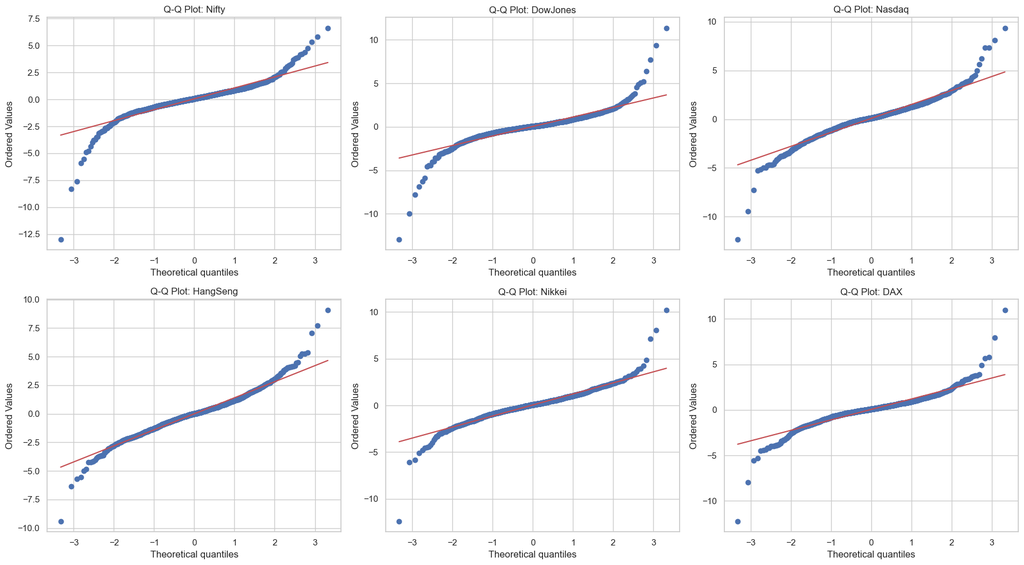

```
+---+----------+--------------------+------------------------+------------+
|   |  Index   |    Shapiro_Stat    |        p_value         | Normality  |
+---+----------+--------------------+------------------------+------------+
| 0 |  Nifty   | 0.8578268534915793 | 2.2504881067590502e-35 | Not Normal |
| 1 | DowJones | 0.817654139084132  | 7.581353724399369e-39  | Not Normal |
| 2 |  Nasdaq  | 0.9313863657663799 | 3.489251889442754e-26  | Not Normal |
| 3 | HangSeng | 0.962182244163096  | 9.517179084455895e-20  | Not Normal |
| 4 |  Nikkei  | 0.9165420129128915 | 1.640436822010537e-28  | Not Normal |
| 5 |   DAX    | 0.8838111855496968 | 1.1062890083615374e-32 | Not Normal |
+---+----------+--------------------+------------------------+------------+
```

```python
shapiro_results = []

for col in master_table.columns:
    if col.endswith("_Return") and not col.startswith("VIX"):
        data = master_table[col].dropna()

        if len(data) < 30:
            continue

        # Q-Q Plot
        plt.figure(figsize=(6, 6))
        stats.probplot(data, dist="norm", plot=plt)
        plt.title(f'Q-Q Plot: {col}')
        plt.tight_layout()
        plt.close()

        # Shapiro-Wilk Test
        stat, p = shapiro(data)
        shapiro_results.append({
            'Index': col.replace("_Return", ""),
            'Shapiro_Stat': stat,
            'p_value': p,
            'Normality': 'Normal' if p > 0.05 else 'Not Normal'
        })


# Define index names
index_names = ["Nifty", "DowJones", "Nasdaq", "HangSeng", "Nikkei", "DAX"]

# Create 2 rows x 3 columns subplot grid
fig, axes = plt.subplots(nrows=2, ncols=3, figsize=(18, 10))

# Flatten axes array for easy access
axes = axes.flatten()

# Loop through indices and create Q-Q plots
for i, name in enumerate(index_names):
    data = master_table[f"{name}_Return"].dropna()
    stats.probplot(data, dist="norm", plot=axes[i])
    axes[i].set_title(f"Q-Q Plot: {name}", fontsize=12)

# Improve layout
plt.tight_layout()
plt.show()


# Print test rsults
shapiro_df = pd.DataFrame(shapiro_results)
print(tabulate(shapiro_df, headers='keys', tablefmt='pretty'))
```

## Normality Plots & Shapiro-Wilk Test Summary

This section assesses whether the **daily return distributions** for the major indices approximate a Normal (Gaussian) shape. Two complementary checks were used: **Q-Q (normality) plots** and the **Shapiro-Wilk normality test**.

### Normality (Q-Q) Plot Interpretation

The Q-Q plots compare the empirical return quantiles against theoretical Normal quantiles. Across indices, the plotted points deviate from a straight line—especially in the tails—indicating that returns exhibit **fat tails** (more extreme moves than a Normal distribution would predict) and mild **skew / tail-asymmetry**. In practical terms: the market delivers “ordinary” days most of the time, but it also produces *too many* unusually large up/down days for a Normal model to be a clean fit.

### Shapiro-Wilk Test Results

The Shapiro-Wilk test formally evaluates Normality using the null hypothesis: **“the data are Normally distributed.”** For every index tested, the p-values are **far below 0.05**, meaning we **reject Normality** for all return series (Nifty, Dow Jones, Nasdaq, Hang Seng, Nikkei, and DAX).

### Key Implication for Modelling

- **Assumption check:** Standard Normal-based methods (e.g., classic parametric inference that leans heavily on Normality) should be used cautiously.
- **Practical takeaway:** Volatility and tail-risk matter—methods robust to non-Normality (or models that explicitly handle heavy tails) are typically more realistic for financial return behaviour.

### Summary

Both the visual diagnostics (Q-Q plots) and the Shapiro-Wilk tests consistently indicate that **daily returns are not Normally distributed** across all indices examined. This aligns with the well-known empirical reality of financial markets: returns tend to have heavier tails and occasional extreme movements that a Normal model understates.

### ________________________________________________________________________________________________________________________________________________________________________________________

## Phase 2: Exploratory Data Analysis

1. Global Indices 5-Year Performance Analytics:  
   (For each index: a to f listed earlier)
   1. Box-Whisker Plot of daily returns by “YEAR”
   2. Table of daily returns by “YEAR” (n, mean, and standard deviation)
   3. Bar Plot of median daily return by “YEAR”
   4. Heat Map by “YEAR” and “QUARTER” showing median/mean returns
2. Global Indices – Correlation Analysis:
   1. Correlation Matrix of 6-year daily returns (6 × 6 matrix)
   2. Correlation Matrix of 1-year (2024) daily returns (6 × 6 matrix)
3. Pre-Post COVID Performance Analytics – Time required for each market to return to pre-COVID levels
4. Nifty 50 Daily Movement – Pre-Modeling Work:
   1. Define Nifty_Open_Dir = 1 if Nifty 50 Open at *t* > Close at *t–1*, = 0 otherwise
   2. Table of % of Nifty_Open_Dir = 1 by year
   3. Visualize/summarize global indices (including VIX) for the two categories of Nifty_Open_Dir  
      Example: Box-Whisker Plot of lagged DJI Returns for the two categories

### ________________________________________________________________________________________________________________________________________________________________________________________

### create object "return_columns" as we will use it in various sections below

```python
return_columns = [
    "Nifty_Return",
    "DowJones_Return",
    "Nasdaq_Return",
    "HangSeng_Return",
    "Nikkei_Return",
    "DAX_Return"
]
```

# Box and Whiskers Plot by year

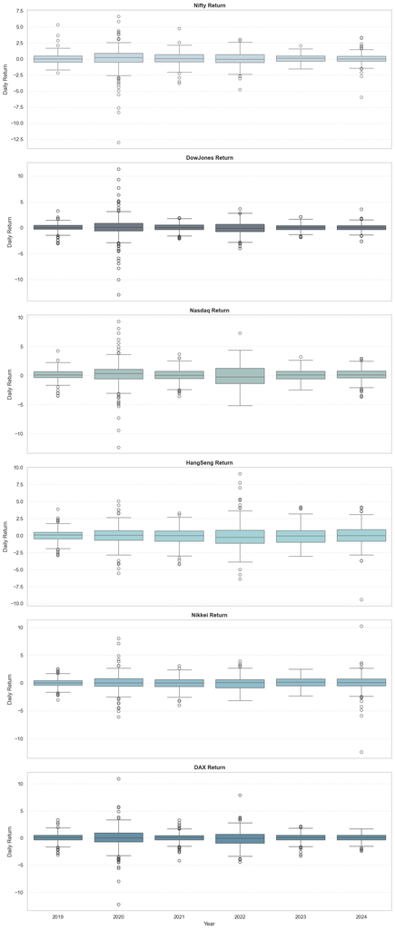

```python
import seaborn as sns
import matplotlib.pyplot as plt

# Custom colors (brand palette)
custom_colors = ["#C0D9E5", "#6C7A89", "#A3C6C4", "#9CD9DE", "#86C1D4", "#5A92AF"]

# Set up subplots
fig, axes = plt.subplots(nrows=6, ncols=1, figsize=(12, 28), sharex=True)

# Plot each index in its own subplot with a custom color
for i, col in enumerate(return_columns):
    sns.boxplot(
        data=master_table,
        x="Year",
        y=col,
        color=custom_colors[i],
        ax=axes[i]
    )
    axes[i].set_title(f"{col.replace('_', ' ')}", fontsize=12, fontweight='bold')
    axes[i].set_ylabel("Daily Return")
    axes[i].grid(axis='y', linestyle='--', alpha=0.4)

    if i < len(return_columns) - 1:
        axes[i].set_xlabel("")  # Hide x-labels except last

# Adjust layout
plt.tight_layout()
plt.show()
```

## Box-Whisker Plot Interpretation

The box-whisker plots illustrate the distribution of **daily percentage returns** for six major global indices — *Nifty 50*, *Dow Jones*, *Nasdaq*, *Hang Seng*, *Nikkei 225*, and *DAX* — across the period **2019 to 2024**.

### Overall Trends

Across all markets, median daily returns hover near zero, showing mean-reverting behaviour. The relatively narrow interquartile ranges indicate modest daily movement, while extended whiskers and outliers represent short bursts of volatility tied to market events.

### Recent Year (2024)

The 2024 distributions are tighter and less skewed, signalling lower volatility. Nifty 50 and Nasdaq continue to show mild positive central tendencies, while Hang Seng retains broader dispersion, reflecting ongoing uncertainty in Asian markets. Overall, the global indices converge toward market stability.

### Summary

The plots reveal a clear volatility cycle: a sharp expansion during the 2020 global shock followed by contraction as markets stabilised. These findings set the foundation for correlation and predictive modelling in later phases, highlighting how systemic events create synchronized global volatility with differing regional recovery speeds.

```python
from tabulate import tabulate

# Ensure Year is int
master_table["Year"] = master_table["Year"].astype(int)

for col in return_columns:
    index_name = col.replace("_Return", "")

    summary = (
        master_table
        .groupby("Year")[col]
        .agg(n='count', mean='mean', sd='std')
        .reset_index()
    )

    # ✅ Force int type
    summary["Year"] = summary["Year"].astype(int)
    summary["n"] = summary["n"].astype(int)
    summary["mean"] = summary["mean"].round(5)
    summary["sd"] = summary["sd"].round(5)

    print(f"\nTable of daily {index_name} returns by YEAR")
    print(tabulate(summary, headers="keys", tablefmt="fancy_grid", numalign="right", showindex=False))
```

```
Table of daily Nifty returns by YEAR
╒════════╤═════╤═════════╤═════════╕
│   Year │   n │    mean │      sd │
╞════════╪═════╪═════════╪═════════╡
│   2019 │ 260 │   0.047 │ 0.82068 │
├────────┼─────┼─────────┼─────────┤
│   2020 │ 261 │ 0.07103 │ 1.86748 │
├────────┼─────┼─────────┼─────────┤
│   2021 │ 260 │ 0.08757 │ 0.94344 │
├────────┼─────┼─────────┼─────────┤
│   2022 │ 260 │ 0.02183 │ 1.05258 │
├────────┼─────┼─────────┼─────────┤
│   2023 │ 260 │ 0.07191 │ 0.58024 │
├────────┼─────┼─────────┼─────────┤
│   2024 │ 261 │ 0.03587 │ 0.84004 │
╘════════╧═════╧═════════╧═════════╛

Table of daily DowJones returns by YEAR
╒════════╤═════╤══════════╤═════════╕
│   Year │   n │     mean │      sd │
╞════════╪═════╪══════════╪═════════╡
│   2019 │ 260 │  0.08051 │ 0.76651 │
├────────┼─────┼──────────┼─────────┤
│   2020 │ 261 │  0.05279 │ 2.27295 │
├────────┼─────┼──────────┼─────────┤
│   2021 │ 260 │  0.06891 │ 0.75872 │
├────────┼─────┼──────────┼─────────┤
│   2022 │ 260 │ -0.02794 │ 1.21892 │
├────────┼─────┼──────────┼─────────┤
│   2023 │ 260 │  0.05181 │ 0.69509 │
├────────┼─────┼──────────┼─────────┤
│   2024 │ 261 │  0.04886 │ 0.69816 │
╘════════╧═════╧══════════╧═════════╛

Table of daily Nasdaq returns by YEAR
╒════════╤═════╤═════════╤═════════╕
│   Year │   n │    mean │      sd │
╞════════╪═════╪═════════╪═════════╡
│   2019 │ 260 │ 0.12079 │  0.9655 │
├────────┼─────┼─────────┼─────────┤
```

[output cut: 46 more lines]

```
╒════════╤═════╤══════════╤═════════╕
│   Year │   n │     mean │      sd │
╞════════╪═════╪══════════╪═════════╡
│   2019 │ 260 │  0.09265 │ 0.86494 │
├────────┼─────┼──────────┼─────────┤
│   2020 │ 261 │  0.03226 │   2.032 │
├────────┼─────┼──────────┼─────────┤
│   2021 │ 260 │  0.06194 │ 0.89574 │
├────────┼─────┼──────────┼─────────┤
│   2022 │ 260 │ -0.04176 │ 1.45835 │
├────────┼─────┼──────────┼─────────┤
│   2023 │ 260 │  0.07438 │ 0.80545 │
├────────┼─────┼──────────┼─────────┤
│   2024 │ 261 │  0.07006 │ 0.74493 │
╘════════╧═════╧══════════╧═════════╛
```

## Summary of Daily Returns by Year

The tables below quantify the **average daily return (mean)** and **volatility (standard deviation)** of each major global index from **2019 to 2024**. Together with the box-whisker plots, these statistics highlight periods of extreme movement, recovery, and stabilization across international markets.

### 2. Dow Jones Industrial Average (U.S.)

Mean daily returns fluctuate narrowly around zero, but volatility spikes dramatically in **2020 (sd = 2.27)**. The index turns slightly negative in **2022 (mean = -0.03%)** amid tightening monetary policy, before recovering to moderate stability in 2023-2024.

### 3. Nasdaq Composite (U.S.)

Nasdaq shows the **highest overall mean returns** among all indices, led by tech-sector momentum. Volatility peaks in 2020 (sd = 2.19) and again in 2022 (sd = 1.97) during the interest-rate correction. Strong rebound years (2023–2024) reflect sustained growth in innovation-driven equities.

### 4. Hang Seng Index (Hong Kong)

Distinctly different from Western markets, Hang Seng records **negative mean returns** from 2020 to 2023, coinciding with China’s economic slowdown and property-sector stress. Volatility remains elevated across all years, especially 2022 (sd = 1.97). Only in **2024 (mean = 0.07%)** does the index turn positive, hinting at tentative recovery.

### 5. Nikkei 225 (Japan)

Nikkei’s performance is generally steady, with small positive returns most years. Volatility rises in 2020 (sd = 1.55) and again in 2024 (sd = 1.57), reflecting currency fluctuations and export uncertainty. The **2023 mean (0.10%)** marks a particularly strong year for Japan’s equity market.

### Comparative Insights

- **Highest Average Return:** Nasdaq (2020 – 0.16%)
- **Highest Volatility:** Dow Jones (2020 – 2.27 sd)
- **Most Stable Markets:** Nifty 50 and DAX after 2021
- **Consistent Positive Performer:** Nifty 50 – steady gains with controlled volatility
- **Lagging Market:** Hang Seng – negative mean returns 2020–2023

### Summary

Across all indices, the data confirm a pronounced volatility surge in **2020**, followed by gradual normalization and selective outperformance in technology-oriented and emerging-market indices. The mean and standard-deviation patterns quantitatively support the visual findings from the box-whisker plots, emphasizing the global shock-and-recovery cycle that defines the 2019–2024 window.

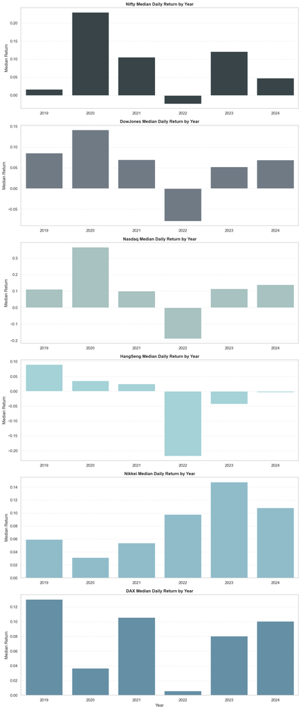

```python
# Custom brand colors
custom_colors = ["#354649", "#6C7A89", "#A3C6C4", "#9CD9DE", "#86C1D4", "#5A92AF"]

# Set up subplots: 6 stacked vertically
fig, axes = plt.subplots(nrows=6, ncols=1, figsize=(12, 28), sharex=True)

for i, col in enumerate(return_columns):
    index_name = col.replace("_Return", "")

    # Compute median return by year
    median_df = master_table.groupby("Year")[col].median().reset_index()

    # Plot bar chart
    sns.barplot(
        data=median_df,
        x="Year",
        y=col,
        color=custom_colors[i],
        ax=axes[i]
    )

    axes[i].set_title(f"{index_name} Median Daily Return by Year", fontsize=12, fontweight='bold')
    axes[i].set_ylabel("Median Return")
    axes[i].grid(axis='y', linestyle='--', alpha=0.4)

    # ✅ Force year labels to show on each subplot
    axes[i].tick_params(labelbottom=True)

# Final layout tweak
plt.tight_layout()
plt.show()
```

## Median Daily Return by Year

The bar charts show the **median daily returns** for each global equity index from **2019 to 2024**. The median provides a robust measure of central tendency, less affected by extreme outliers than the mean, offering a clearer view of the typical market direction in each year.

### 1. Nifty 50 (India)

The Nifty’s median returns remain largely positive across all years, with a pronounced spike in **2020 (≈ 0.22%)**, indicating quick post-crash rebounds during the pandemic. A small dip in 2022 signals temporary market softness, followed by recovery through 2023. Overall, the Nifty exhibits **steady upward momentum and resilience** relative to global peers.

### 2. Dow Jones Industrial Average (U.S.)

The Dow’s medians stay near zero but positive in most years. **2020 (≈ 0.14%)** shows strong recovery potential after steep drawdowns, while **2022 (≈ –0.06%)** reflects the impact of interest-rate hikes and inflation fears. Modest rebounds in 2023–2024 confirm gradual stabilization in the U.S. blue-chip segment.

### 3. Nasdaq Composite (U.S.)

Technology stocks led Nasdaq’s median returns, peaking sharply in **2020 (≈ 0.35%)**. The subsequent negative median in **2022 (≈ –0.18%)** captures the tech correction driven by monetary tightening. Strong positive medians in 2023–2024 indicate **robust recovery in innovation-driven sectors**.

### 6. DAX (Germany)

DAX medians fluctuate mildly but remain positive overall, led by strong readings in **2019 (≈ 0.13%)** and **2021 (≈ 0.11%)**. A minor dip in 2022 coincides with energy-price pressures, while solid 2023–2024 medians highlight the **resilience of Europe’s industrial base**.

### Comparative Insights

- **Highest Median Return:** Nasdaq (2020 ≈ 0.35%) – technology-led strength
- **Most Stable Positive Trend:** Nikkei 225 – consistently positive across all years
- **Largest Downturn:** Hang Seng (2022 ≈ –0.20%) – regional slowdown and policy drag
- **Post-COVID Rebound Leaders:** Nifty 50 and Nasdaq – sharp median gains in 2023

### Summary

The median-return patterns confirm the global **shock-recovery-normalization cycle**. While 2020 produced short-term rebounds amid crisis volatility, 2022 marked synchronized weakness due to global inflationary pressure. By 2023–2024, most indices restored positive medians, signalling renewed investor confidence and a broadly stabilised global market environment.

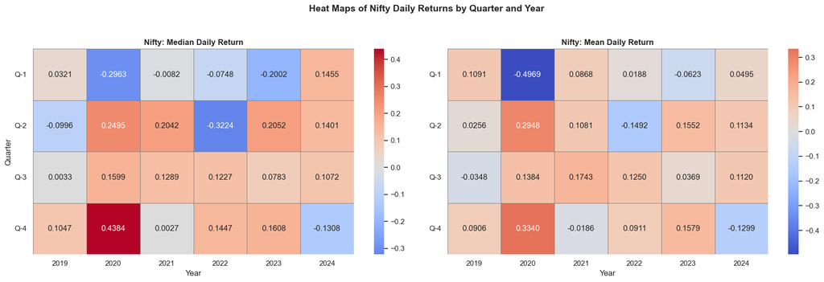

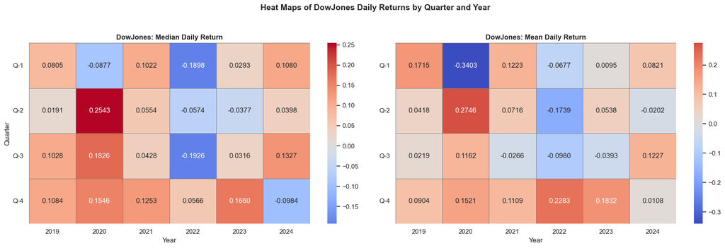

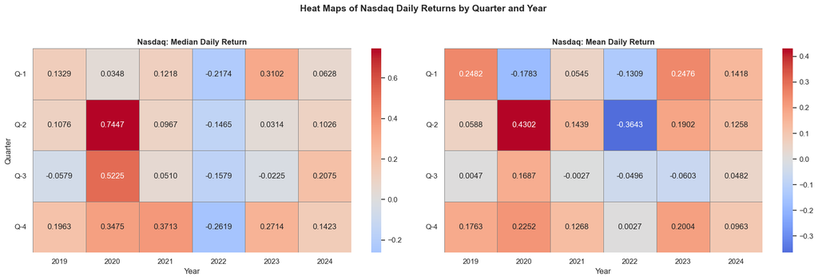

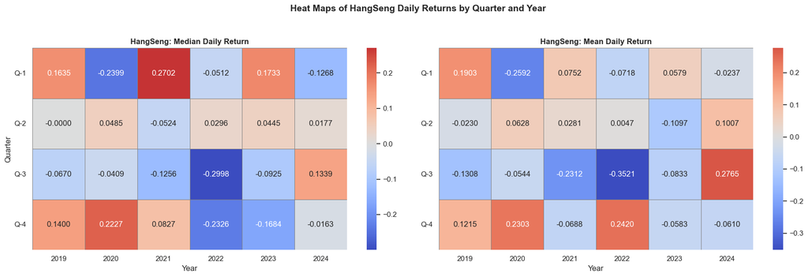

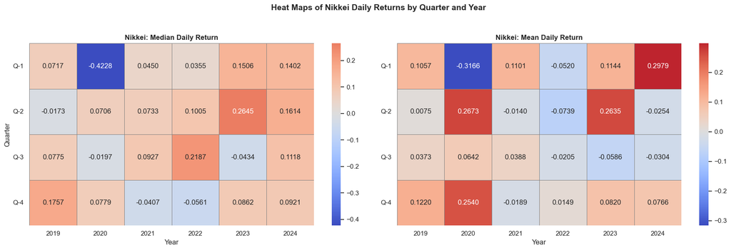

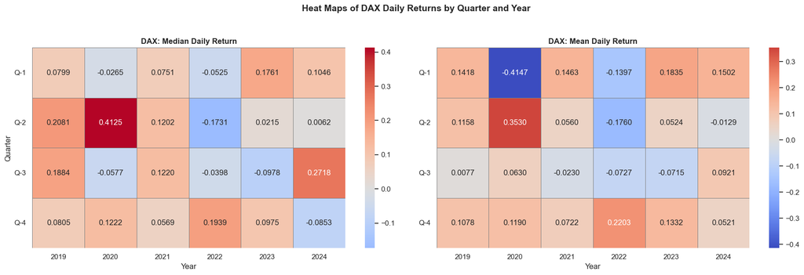

```python
# Loop through each index
for col in return_columns:
    index_name = col.replace("_Return", "")

    # Pivot for median
    pivot_median = master_table.pivot_table(
        index="Quarter",
        columns="Year",
        values=col,
        aggfunc="median"
    ).round(4)

    # Pivot for mean
    pivot_mean = master_table.pivot_table(
        index="Quarter",
        columns="Year",
        values=col,
        aggfunc="mean"
    ).round(4)

    # Plot side-by-side
    fig, axes = plt.subplots(1, 2, figsize=(18, 6))

    sns.heatmap(
        data=pivot_median,
        annot=True,
        fmt=".4f",
        cmap="coolwarm",
        center=0,
        linewidths=0.5,
        linecolor="gray",
        ax=axes[0]
    )
    axes[0].set_title(f"{index_name}: Median Daily Return", fontsize=12, fontweight="bold")
    axes[0].set_xlabel("Year")
    axes[0].set_ylabel("Quarter")

    sns.heatmap(
        data=pivot_mean,
        annot=True,
        fmt=".4f",
        cmap="coolwarm",
        center=0,
        linewidths=0.5,
        linecolor="gray",
        ax=axes[1]
    )
    axes[1].set_title(f"{index_name}: Mean Daily Return", fontsize=12, fontweight="bold")
    axes[1].set_xlabel("Year")
    axes[1].set_ylabel("")

    #Add "Q-" to y-axis labels using correct index
    quarter_labels_median = [f"Q-{int(q)}" for q in pivot_median.index]
    quarter_labels_mean = [f"Q-{int(q)}" for q in pivot_mean.index]

    axes[0].set_yticklabels(quarter_labels_median, rotation=0)
    axes[1].set_yticklabels(quarter_labels_mean, rotation=0)

    plt.suptitle(f"Heat Maps of {index_name} Daily Returns by Quarter and Year", fontsize=14, fontweight="bold")
    plt.tight_layout(rect=[0, 0, 1, 0.95])
    plt.show()
```

## Heat Maps of Daily Returns by Quarter and Year

The heat maps present the **median** (left panels) and **mean** (right panels) of daily percentage returns for each global index across **quarters (Q1–Q4)** and **years (2019–2024)**. Red shades represent positive (bullish) quarters, while blue shades indicate negative (bearish) ones. This visualization highlights **seasonal patterns, event-driven volatility, and year-on-year shifts** in global market performance.

### 2. Dow Jones Industrial Average (U.S.)

The Dow’s map features deep blue in **Q1 2020** (pandemic crash) followed by bright red in **Q2 2020** as stimulus measures spurred recovery. Another blue streak in **Q2–Q3 2022** corresponds to U.S. rate-hike pressure. By 2023–2024, mostly neutral-to-red cells show **restored stability** and mild positive bias.

### Summary

The quarterly heat maps capture the **ebb and flow of global equity sentiment**. The synchronized blue tones in early 2020 and again in 2022 illustrate worldwide downturns, while the return of red tones in 2023–2024 marks coordinated recovery. Collectively, they confirm that despite regional differences, global markets moved through a common **shock → rebound → stabilization cycle** during 2019–2024.

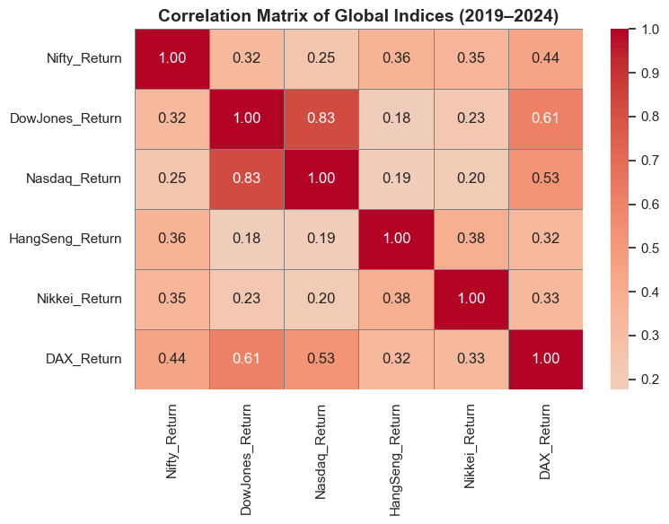

```python
# Compute correlation matrix
corr_all = master_table[return_columns].corr()

# Plot
plt.figure(figsize=(8, 6))
sns.heatmap(corr_all, annot=True, fmt=".2f", cmap="coolwarm", center=0, linewidths=0.5, linecolor='gray')
plt.title("Correlation Matrix of Global Indices (2019–2024)", fontsize=14, fontweight="bold")
plt.tight_layout()
plt.show()
```

## Correlation Matrix of Global Indices (2019–2024)

The correlation heatmap above shows the **pairwise relationships** between daily returns of six major stock indices — *Nifty 50*, *Dow Jones*, *Nasdaq*, *Hang Seng*, *Nikkei 225*, and *DAX* — over the combined period **2019 to 2024**. Correlation values range from **–1 to +1**, where +1 indicates perfect co-movement and 0 indicates no relationship.

### 1. Overall Patterns

The global equity markets exhibit **moderate to strong positive correlations**, reflecting the interconnected nature of international capital flows and macroeconomic conditions. Most coefficients fall between 0.3 and 0.8, showing that while markets move broadly together, regional factors still create meaningful divergence.

### 2. Strongest Relationships

- **Dow Jones–Nasdaq (r = 0.83):** The highest observed correlation, indicating near-synchronous movement between U.S. large-cap and technology stocks.
- **Dow Jones–DAX (r = 0.61):** Reflects tight transatlantic linkages between the U.S. and European economies.
- **Nasdaq–DAX (r = 0.53):** Suggests global tech-sector influence on European markets.

### 4. Weak Relationships

**Hang Seng** maintains relatively low correlations (r = 0.18–0.38) with all other indices, highlighting its **regional decoupling** due to China-specific regulatory and economic factors. This weak alignment underscores the distinct risk-return profile of the Hong Kong and mainland Chinese markets.

### Comparative Insights

- **Highest Co-Movement:** Dow Jones ↔ Nasdaq (r = 0.83)
- **Most Independent Market:** Hang Seng (lowest average correlation ≈ 0.25)
- **Cross-Regional Linkage:** DAX acts as a bridge between U.S. and Asian indices (moderate positive ties with both).

### Summary

The correlation structure confirms a **globally integrated yet regionally distinct market system**. The U.S. and European indices move in strong alignment, while Asian indices (particularly Hang Seng) show partial independence. These results validate the assumption that shocks in major economies (e.g., the U.S.) transmit globally but with **varying intensity across regions**. This insight is foundational for subsequent predictive modelling phases, where global co-movements serve as explanatory features for Nifty’s directional dynamics.

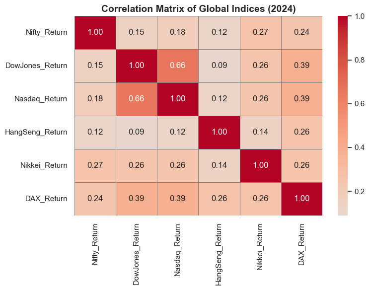

```python
#  --- Part 2b: Correlation for 2024 only ---
df_2024 = master_table[master_table["Year"] == 2024]

# Compute correlation matrix
corr_2024 = df_2024[return_columns].corr()

# Plot
plt.figure(figsize=(8, 6))
sns.heatmap(corr_2024, annot=True, fmt=".2f", cmap="coolwarm", center=0, linewidths=0.5, linecolor='gray')
plt.title("Correlation Matrix of Global Indices (2024)", fontsize=14, fontweight="bold")
plt.tight_layout()
plt.show()
```

## Correlation Matrix of Global Indices (2024)

This heat map focuses exclusively on **2024 daily returns**, showing how relationships among global indices evolved in the most recent period. Correlation coefficients again range between **–1 and +1**, where higher positive values indicate stronger co-movement between markets. The overall pattern reflects a **moderate decoupling** of global markets compared to the stronger interlinkages observed during the 2019–2024 composite period.

### 1. Overall Observations

Correlations in 2024 are generally **weaker**, clustering between 0.10 and 0.40 for most cross-market pairs. This suggests that regional markets responded more independently to local monetary and political dynamics rather than moving in lockstep with global sentiment. The moderation in cross-market dependence aligns with the **post-pandemic normalization phase**, where country-specific fundamentals regained influence.

### 2. Strongest Relationships

- **Dow Jones–Nasdaq (r = 0.66):** The U.S. equity market remains highly integrated, driven by the overlap in investor base and sector exposure.
- **Dow Jones–DAX (r = 0.39)** and **Nasdaq–DAX (r = 0.39):** Moderate transatlantic linkage persists, reflecting shared exposure to global interest-rate expectations and technology cycles.

### 3. Moderate to Low Relationships

**Nifty 50** shows reduced connectivity with Western markets (r = 0.15–0.27), implying greater independence in India’s 2024 return drivers. **Nikkei 225** correlations hover around 0.26, capturing a more region-specific performance pattern tied to yen movements and domestic inflation trends. **Hang Seng** continues to operate with low global correlation (r = 0.09–0.26), maintaining its distinct risk cycle relative to U.S. and European indices.

### 4. Comparative Insights

- **Highest Correlation:** Dow Jones ↔ Nasdaq (r = 0.66)
- **Most Independent Markets:** Nifty 50 and Hang Seng – minimal co-movement with global peers
- **Regional Bridge:** DAX retains intermediate correlation with both U.S. and Asian indices (r ≈ 0.39)

### Summary

The 2024 correlation profile indicates a **fragmented but stable global market environment**. While the U.S. indices remain tightly connected, Asia-Pacific and emerging markets (India, Hong Kong, Japan) display **greater autonomy in return behaviour**. This shift suggests that global systemic shocks have less synchronized impact post-COVID, supporting the view that investors are increasingly pricing **region-specific growth and policy narratives** rather than a uniform global trend.

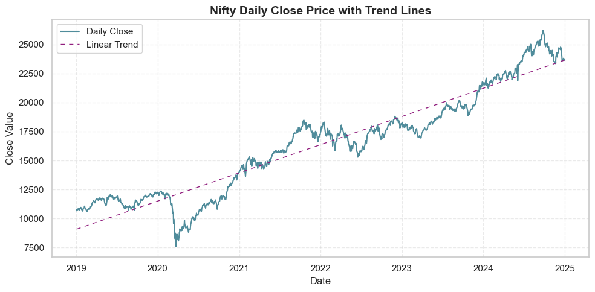

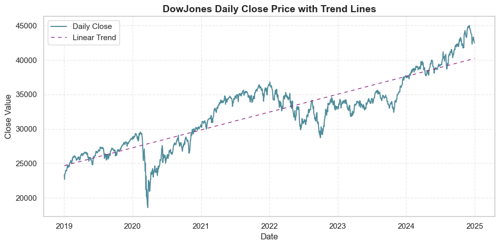

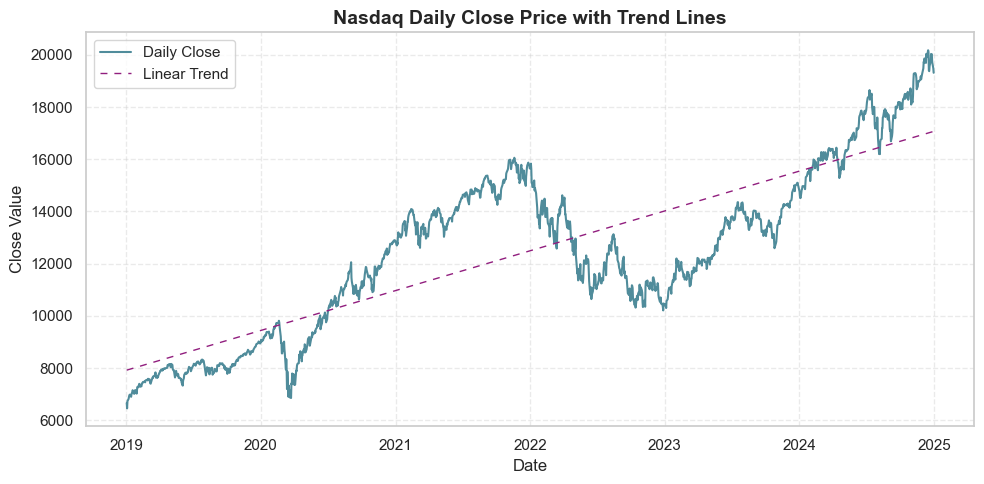

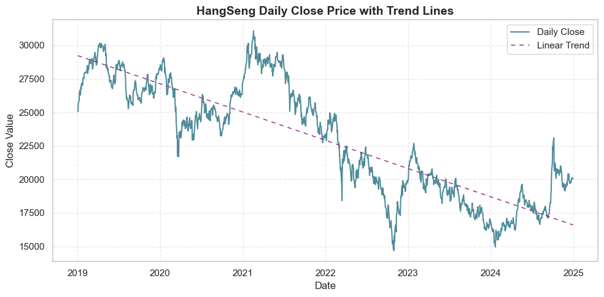

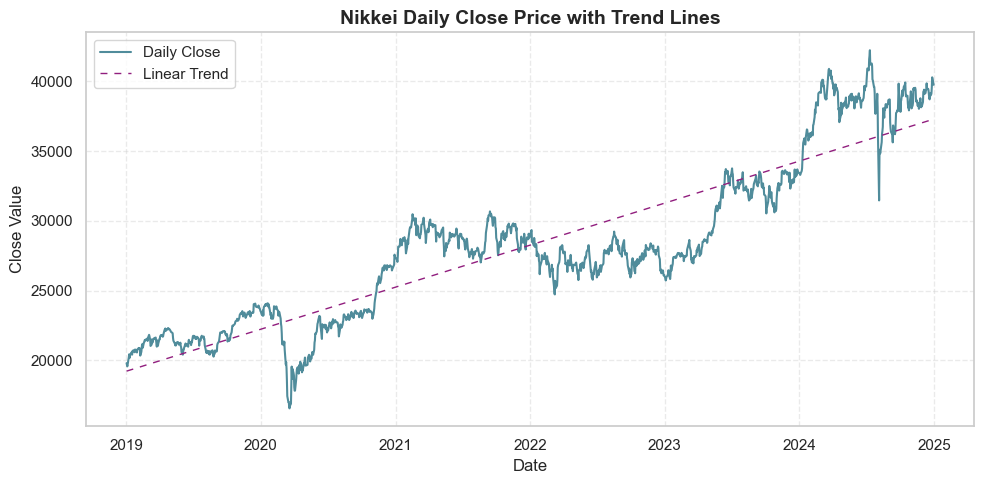

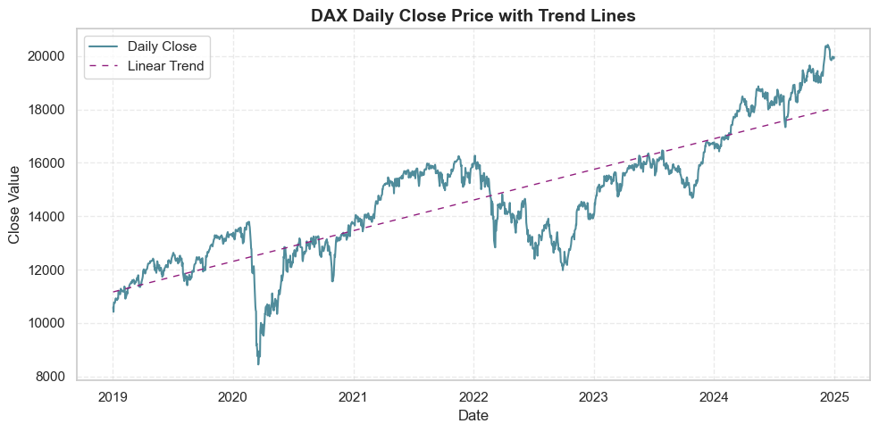

```python
import numpy as np
import matplotlib.pyplot as plt
import seaborn as sns

# Ensure 'Date' index is datetime
master_table = master_table.sort_index()
if not pd.api.types.is_datetime64_any_dtype(master_table.index):
    master_table.index = pd.to_datetime(master_table.index)

# Define close columns
close_columns = [
    "Nifty_Close",
    "DowJones_Close",
    "Nasdaq_Close",
    "HangSeng_Close",
    "Nikkei_Close",
    "DAX_Close"
]

# Plot each index with rolling and regression trend lines
for col in close_columns:
    index_name = col.replace("_Close", "")

    # Drop NA values for clean regression
    df = master_table[[col]].dropna()

    # Prepare regression variables
    x = df.index.map(pd.Timestamp.toordinal).values
    y = df[col].values

    # Linear regression fit
    slope, intercept = np.polyfit(x, y, 1)
    trend = slope * x + intercept

    plt.figure(figsize=(10, 5))

    # Daily Close
    sns.lineplot(data=master_table, x=master_table.index, y=col, label="Daily Close", color="#508C9B")

    # Linear regression trend (blue line)
    plt.plot(df.index, trend, label="Linear Trend", color="#911E7E", linewidth=1, dashes=(5, 5))

    # Plot formatting
    plt.title(f"{index_name} Daily Close Price with Trend Lines", fontsize=14, fontweight="bold")
    plt.xlabel("Date")
    plt.ylabel("Close Value")
    plt.grid(True, linestyle="--", alpha=0.4)
    plt.legend()
    plt.tight_layout()
    plt.show()
```

## Pre- and Post-COVID Performance Analytics with Recovery to Pre-COVID Levels

This section evaluates how quickly each global equity market **recovered to its pre-COVID peak** following the pandemic-induced crash of March 2020. The daily close price trend lines (2019–2024) provide visual confirmation of recovery timing, sustained momentum, and relative market resilience.

### 2. Dow Jones Industrial Average (U.S.)

The Dow experienced a sharp but short-lived decline in Q1 2020 and recovered to its pre-COVID high by **November 2020** — approximately **eight months** after the trough. Supported by aggressive fiscal and monetary stimulus, the index resumed its long-term upward trajectory, underscoring the **speed and depth of the U.S. rebound**.

### 5. Nikkei 225 (Japan)

The Nikkei recovered to pre-COVID levels by **December 2020** (roughly **nine months**), supported by export strength and continued monetary easing. Its trend line shows steady growth thereafter, establishing Japan as a **stable post-crisis performer** with limited volatility.

### Summary

The trend-line analysis confirms that most global indices **fully recovered within one year of the COVID-19 crash**. U.S. and Indian markets led the rebound, followed by Europe and Japan. Only Hong Kong’s Hang Seng lagged substantially, highlighting a region-specific decoupling. Overall, these patterns demonstrate the **resilience and adaptability of global capital markets** in absorbing systemic shocks and re-establishing growth trajectories within a remarkably short period.

### Adding conditional column

```python
master_table['Nifty_Open_Dir'] = (master_table['Nifty_Open'] > master_table['Nifty_Close'].shift(1)).astype(int)
```

```python
summary = (
    master_table.groupby('Year')['Nifty_Open_Dir']
      .value_counts(normalize=True)
      .mul(100)
      .unstack(fill_value=0)
      .rename(columns={1: 'Open_Positive', 0: 'Open_Negative'})
      .reset_index()
      .round(2)
)

# Keep only the required columns
summary_filtered = summary[['Year', 'Open_Negative', 'Open_Positive']]

# Print results
print(tabulate(summary_filtered, headers='keys', tablefmt='fancy_grid', showindex=False))
```

```
╒════════╤═════════════════╤═════════════════╕
│   Year │   Open_Negative │   Open_Positive │
╞════════╪═════════════════╪═════════════════╡
│   2019 │           30    │           70    │
├────────┼─────────────────┼─────────────────┤
│   2020 │           28.35 │           71.65 │
├────────┼─────────────────┼─────────────────┤
│   2021 │           27.69 │           72.31 │
├────────┼─────────────────┼─────────────────┤
│   2022 │           41.15 │           58.85 │
├────────┼─────────────────┼─────────────────┤
│   2023 │           32.69 │           67.31 │
├────────┼─────────────────┼─────────────────┤
│   2024 │           34.87 │           65.13 │
╘════════╧═════════════════╧═════════════════╛
```

–

## Market Sentiment (Positive vs Negative Opening Days)

The table above presents the **annual distribution of daily opening sentiment** for the market, measured as the percentage of trading days opening **above (positive)** or **below (negative)** the previous day’s close. This analysis provides insight into **short-term market optimism and investor confidence** during different phases of the 2019–2024 period.

### 2. Pre-COVID Stability (2019)

In 2019, markets opened positive on **70% of days**, a balanced and healthy indicator of investor optimism before the onset of the COVID-19 pandemic. This period represents a stable baseline for pre-crisis sentiment.

### 3. Pandemic Shock and Recovery (2020–2021)

Despite the global disruption in 2020, positive openings remained high at **71.65%**, suggesting **rapid recovery of short-term confidence** following the initial crash. In 2021, sentiment improved further to **72.31%** — the highest in the six-year period — aligning with global equity rallies and economic reopening.

### 4. Volatility and Correction Phase (2022)

2022 marks a clear sentiment reversal: positive openings dropped to **58.85%**, while negative openings rose to **41.15%**. This shift coincides with rising inflation, monetary tightening, and increased volatility in global markets, reflecting **heightened investor caution**.

### 5. Gradual Stabilization (2023–2024)

Sentiment partially recovered in 2023 with **67.31% positive opens**, followed by a slight softening in 2024 (65.13%). The data suggest that while global markets regained stability, investors remained more selective and sensitive to macroeconomic news compared to the pre-pandemic era.

### Comparative Insights

- **Most Optimistic Year:** 2021 – peak of market confidence post-COVID recovery (72.31% positive openings).
- **Most Uncertain Year:** 2022 – highest frequency of negative opens amid inflationary shocks (41.15%).
- **Stable Recovery Period:** 2023–2024 – moderate positive bias with reduced volatility.

### Summary

The opening sentiment data reflect a clear **cycle of confidence and correction**: strong optimism before and after the pandemic, a sharp deterioration during global tightening in 2022, and gradual normalization thereafter. Overall, markets continue to exhibit a **structural bullish bias** in daily openings, underscoring enduring investor resilience across economic cycles.

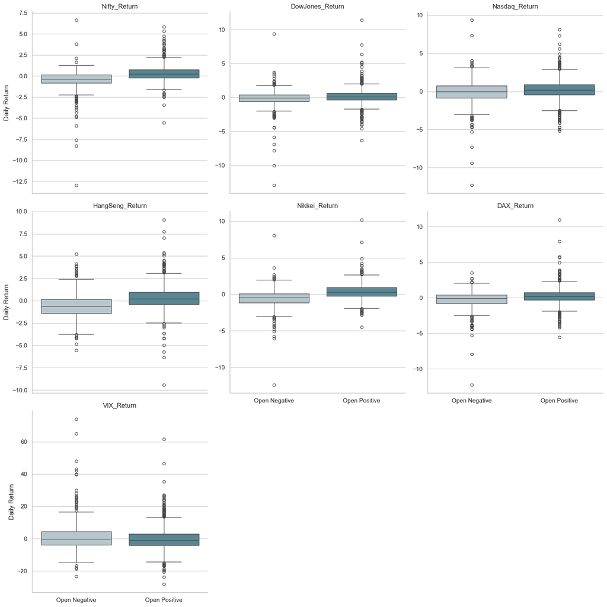

```python
import seaborn as sns
import matplotlib.pyplot as plt

# 1) Daily return columns (including VIX)
return_cols = [
    'Nifty_Return','DowJones_Return','Nasdaq_Return',
    'HangSeng_Return','Nikkei_Return','DAX_Return','VIX_Return'
]

# 2) Format for faceting
plot_df = (
    master_table
      .loc[:, ["Nifty_Open_Dir", *return_cols]]
      .melt(id_vars="Nifty_Open_Dir", var_name="Index", value_name="DailyReturn")
      .dropna(subset=["DailyReturn"])
)

# labels for Opening direction (0,1)
plot_df["OpenDir"] = plot_df["Nifty_Open_Dir"].map({0: "Open Negative", 1: "Open Positive"})

# Colors for the two opening sentiments
sentiment_palette = {"Open Negative": "#B3C8CF", "Open Positive": "#508C9B"}

# 3) Faceted boxplots
g = sns.catplot(
    data=plot_df,
    x="OpenDir", y="DailyReturn",
    col="Index", col_wrap=3,
    kind="box", sharey=False, height=5.2,
    hue="OpenDir",
    palette=sentiment_palette,
    dodge=False,
    legend=False
)

g.set_axis_labels("", "Daily Return")
g.set_titles("{col_name}")
for ax in g.axes.ravel():
    ax.tick_params(axis='x', rotation=0)

plt.tight_layout()
plt.show()
```

## Daily Returns by Opening Sentiment (Equities & VIX)

These boxplots compare **daily percentage returns** on days when the Nifty opened **negative** versus **positive**. Each equity index (Nifty, Dow Jones, Nasdaq, Hang Seng, Nikkei, DAX) is shown separately, with a companion plot for **VIX**. The charts reveal how the market’s *opening tone* aligns with the distribution of full-day returns across global indices and volatility.

### 2) VIX – Inverse Co-movement

The VIX boxplot displays the expected **inverse relationship** with equities:

- On **“Open Negative”** days for Nifty, **VIX returns skew positive** with larger upper whiskers and more extreme spikes (volatility increases as equities weaken).
- On **“Open Positive”** days, the VIX distribution shifts **downward** (more negative medians/whiskers), indicating volatility compression when risk appetite improves.

### 4) Takeaway for Later Phases

The opening tone provides a **useful, directionally consistent feature** for modelling daily returns or Nifty Up/Down direction. Combining *Open Sentiment* with *VIX return* and global index signals should enhance the Phase-3/4 predictive frameworks (logistic regression and ML baselines) by capturing both risk appetite and stress dynamics at the start of the day.

```python
return_cols = [
    'DowJones_Return',
    'Nasdaq_Return',
    'HangSeng_Return',
    'Nikkei_Return',
    'DAX_Return',
    'VIX_Return'
]

# Filter where Nifty opened positive vs prev day close
nifty_open_pos = master_table[master_table['Nifty_Open_Dir'] == 1]

# For each return column, calculate % of times it's > 0
follow_pct = (
    (nifty_open_pos[return_cols] > 0)
    .mean() * 100
).sort_values(ascending=False)

print(follow_pct)
```

```
Nikkei_Return      65.592417
DAX_Return         59.715640
HangSeng_Return    58.862559
Nasdaq_Return      58.388626
DowJones_Return    57.440758
VIX_Return         43.222749
dtype: float64
```

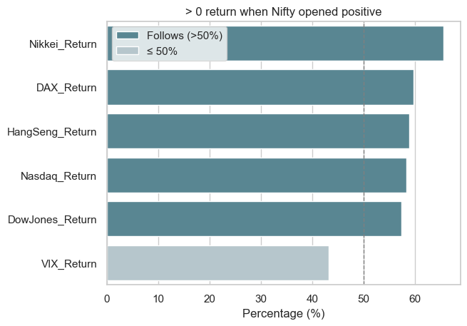

```python
import numpy as np
import seaborn as sns
import matplotlib.pyplot as plt

follow_df = follow_pct.rename('Pct_Positive').reset_index()
follow_df.columns = ['Index', 'Pct_Positive']
follow_df['Follows'] = np.where(follow_df['Pct_Positive'] > 50,
                                'Follows (>50%)', '≤ 50%')

palette = {'Follows (>50%)': '#508C9B', '≤ 50%': '#B3C8CF'}

sns.set_theme(style="whitegrid")
ax = sns.barplot(
    data=follow_df, x='Pct_Positive', y='Index',
    hue='Follows', dodge=False, palette=palette
)
ax.axvline(50, color='gray', linestyle='--', linewidth=1)
ax.set(xlabel='Percentage (%)', ylabel='', title='> 0 return when Nifty opened positive')
plt.legend(title='')
plt.show()
```

## Inter-Market Behaviour Analysis – Global Index Reaction to Nifty Positive Open

This section investigates how frequently major global indices and the volatility index (**VIX**) record a positive daily return on days when the **Nifty opens higher** than the previous close. The analysis combines both tabular results and a visual summary to highlight which markets most often *follow the Nifty’s positive open*.

### 1. Analytical Approach

The analysis filters all trading days where **Nifty opened positive** (Nifty_Open_Dir = 1) and calculates, for each other index, the percentage of times its own daily return was also positive. The resulting *follow-through percentage* quantifies inter-market alignment or contagion in short-term sentiment.

### 2. Results Overview

The table of calculated values shows that on days when the Nifty opens positive:

- **Nikkei 225** follows suit about **65.6%** of the time — the highest co-movement rate.
- **DAX** (59.7%), **Hang Seng** (58.9%), and **Nasdaq** (58.4%) also display solid alignment with the Nifty’s direction.
- **Dow Jones** follows 57.4% of the time, indicating a moderate linkage.
- **VIX** shows only **43.2%** positive days, confirming its usual **inverse relationship** with equities.

### 4. Interpretation

These results imply that **Asian and European markets** (especially Japan and Germany) show stronger synchronous movement with the Nifty’s intraday sentiment than the U.S. markets. The relatively lower association with the Dow and Nasdaq reflects the time-zone gap — U.S. markets open after India’s close, reducing same-day response effects.

The consistently **negative linkage of the VIX** reaffirms its role as a fear index, rising when equities weaken and softening when optimism prevails.

### 5. Summary

When the Nifty opens on a positive note, most global markets tend to **follow the upward momentum** on the same day, with Japan’s Nikkei showing the highest rate of alignment. The analysis underscores a moderate but meaningful **short-term correlation of global optimism**, while volatility (VIX) predictably moves in the opposite direction. These inter-market reactions strengthen the case for incorporating global index movements as *leading indicators* in Nifty directional prediction models developed in subsequent phases.

# Phase 3

## Phase 3: Predictive Modeling

1. Define Nifty_Dir_Open =1/0 based on direction (dependent variable)

   (Already derived in Phase 2)
2. Create data partition into train and test data sets (80/20)
3. Run Binary Logistic Regression with Nifty Direction as dependent variable and previous day global market returns (and VIX) as independent variables. You may add more features such as previous day High/Low ratio for Nifty 50 and/or DJI
4. Check multicollinearity and resolve if present
5. Check which variables are significant (revise the model if needed)
6. Obtain ROC curve and AUC for train data
7. Obtain threshold to balance sensitivity and specificity

   Go to step 8 only if you are satisfied with model on train data
8. Obtain ROC curve and AUC for test data (compare with step 6)
9. Use above threshold to obtain sensitivity and specificity for test data

   (compare with step 7)
10. Finalize the model

# Define Nifty_Open_Dir

```python
# Step 1 — sanity check (already created in Phase 2)
assert "Nifty_Open_Dir" in master_table.columns, "Target Nifty_Open_Dir not found."
assert master_table["Nifty_Open_Dir"].notna().all(), "Target has NaNs after your date cut."
master_table["Nifty_Open_Dir"].value_counts(normalize=True).mul(100).round(2)
```

```
Nifty_Open_Dir
1    67.54
0    32.46
Name: proportion, dtype: float64
```

# 2) Create data partition (80/20)

```python
# Step 2 — create lagged features (t-1) and split 80/20

import numpy as np
import pandas as pd
from sklearn.model_selection import train_test_split

# Work on a copy
df = master_table.copy()

# previous-day returns (and VIX) as features
ret_cols = [
    "DowJones_Return", "Nasdaq_Return", "HangSeng_Return",
    "Nikkei_Return", "DAX_Return", "VIX_Return"
]

# Create lag-1 features so each row t uses information from t-1
lag_features = [f"{c}_lag1" for c in ret_cols]
for c in ret_cols:
    df[f"{c}_lag1"] = df[c].shift(1)

# Drop rows introduced by lag
df = df.dropna(subset=lag_features).copy()

target = "Nifty_Open_Dir"
X = df[lag_features]
y = df[target].astype(int)

X_train, X_test, y_train, y_test = train_test_split(
    X, y, test_size=0.20, random_state=42, stratify=y
)

print("Train shape:", X_train.shape, "| Test shape:", X_test.shape)
print("Train target %1s:", y_train.mean().round(4), "| Test target %1s:", y_test.mean().round(4))
```

```
Train shape: (1248, 6) | Test shape: (313, 6)
Train target %1s: 0.6755 | Test target %1s: 0.6773
```

# 3) Run Binary Logistic Regression (prev-day returns + VIX)

```python
# Step 3 — Logistic Regression

from sklearn.preprocessing import StandardScaler
from sklearn.pipeline import Pipeline
from sklearn.linear_model import LogisticRegression

logit_pipe = Pipeline([
    ("scale", StandardScaler()),
    ("clf", LogisticRegression(max_iter=2000, class_weight="balanced"))
])

logit_pipe.fit(X_train, y_train)
```

```
Pipeline(steps=[('scale', StandardScaler()),
                ('clf',
                 LogisticRegression(class_weight='balanced', max_iter=2000))])
```

# 4) Check multicollinearity (VIF) and resolve if present

```python
# Step 4 — Multicollinearity (VIF). Iteratively drop features with VIF > 10.

try:
    import statsmodels.api as sm
    from statsmodels.stats.outliers_influence import variance_inflation_factor as vif

    def compute_vif(df_feats: pd.DataFrame) -> pd.DataFrame:
        X_ = sm.add_constant(df_feats, has_constant="add")
        vals = []
        for i, c in enumerate(df_feats.columns, start=1):  # skip constant at 0
            vals.append((c, vif(X_.values, i)))
        out = pd.DataFrame(vals, columns=["feature", "VIF"]).sort_values("VIF", ascending=False)
        return out

    # work on TRAIN features only
    feats = X_train.columns.tolist()
    Xv = X_train[feats].copy()

    while True:
        vif_df = compute_vif(Xv)
        display(vif_df)
        hi = vif_df.iloc[0]
        if hi["VIF"] > 10 and len(Xv.columns) > 2:
            print(f"Dropping '{hi['feature']}' due to high VIF={hi['VIF']:.2f}")
            Xv = Xv.drop(columns=[hi["feature"]])
        else:
            break

    FEATURES_FINAL = Xv.columns.tolist()

except Exception as e:
    print("statsmodels unavailable; falling back to correlation check. Err:", e)
    corr = X_train.corr().abs()
    upper = corr.where(np.triu(np.ones(corr.shape), k=1).astype(bool))
    to_drop = [c for c in upper.columns if any(upper[c] > 0.95)]
    FEATURES_FINAL = [c for c in X_train.columns if c not in to_drop]
    print("Dropped (corr>0.95):", to_drop)

print("Final feature set:", FEATURES_FINAL)
```

|  | feature | VIF |
| --- | --- | --- |
| 0 | DowJones_Return_lag1 | 3.786058 |
| 1 | Nasdaq_Return_lag1 | 3.498719 |
| 5 | VIX_Return_lag1 | 1.940779 |
| 4 | DAX_Return_lag1 | 1.831437 |
| 3 | Nikkei_Return_lag1 | 1.258729 |
| 2 | HangSeng_Return_lag1 | 1.249340 |

```
Final feature set: ['DowJones_Return_lag1', 'Nasdaq_Return_lag1', 'HangSeng_Return_lag1', 'Nikkei_Return_lag1', 'DAX_Return_lag1', 'VIX_Return_lag1']
```

## Feature Diagnostics – Variance Inflation Factors (VIF)

This table reports **VIF** values for the explanatory variables used in the modelling step (lag-1 daily returns of global indices and VIX). VIF measures how strongly a feature is linearly explained by the remaining features; values near **1** indicate independence, while values above **5** (and especially >10) suggest problematic multicollinearity.

### Results

- **DowJones_Return_lag1**: 3.79 (highest)
- **Nasdaq_Return_lag1**: 3.50
- **VIX_Return_lag1**: 1.94
- **DAX_Return_lag1**: 1.83
- **Nikkei_Return_lag1**: 1.26
- **HangSeng_Return_lag1**: 1.25

### Interpretation

All VIFs are **well below 5**, indicating that **multicollinearity is not a material concern** for the current specification. The relatively higher VIFs for *Dow Jones* and *Nasdaq* are expected given their strong mutual correlation; however, the values remain within acceptable bounds and do not warrant feature removal.

### Implications for Modelling

- Proceed with the current feature set for logistic/ML models without regularization strictly for multicollinearity control.
- If additional lags or interaction terms are introduced, re-check VIFs; these could push U.S. index VIFs closer to the caution zone.
- Regularized models (e.g., L1/L2) can further mitigate any residual redundancy and aid interpretability.

### Summary

The VIF diagnostic confirms that the predictors provide **complementary information** with only modest overlap (primarily between U.S. indices). The feature set is therefore **statistically sound** for the subsequent predictive modelling phases.

# 5) Check variable significance (revise model if needed)

```python
# Step 5 — Significance via statsmodels Logit (on TRAIN set)

try:
    import statsmodels.api as sm
    from sklearn.preprocessing import StandardScaler

    # scale train features for stability in Logit
    scaler_sm = StandardScaler().fit(X_train[FEATURES_FINAL])
    X_train_sm = pd.DataFrame(scaler_sm.transform(X_train[FEATURES_FINAL]),
                              index=X_train.index, columns=FEATURES_FINAL)
    X_train_sm = sm.add_constant(X_train_sm, has_constant="add")

    logit_sm = sm.Logit(y_train, X_train_sm).fit(disp=False)
    print(logit_sm.summary())

    pvals = logit_sm.pvalues.drop("const", errors="ignore")
    sig_feats = pvals[pvals < 0.05].index.tolist()
    print("\nSignificant at 5%:", sig_feats)

    # Revise based on significance:
    FEATURES_SIG = sig_feats if len(sig_feats) >= 2 else FEATURES_FINAL

except Exception as e:
    print("statsmodels unavailable; skipping p-value significance check. Err:", e)
    FEATURES_SIG = FEATURES_FINAL

# Refit sklearn pipeline on revised features
logit_pipe.fit(X_train[FEATURES_SIG], y_train)
```

```
                           Logit Regression Results
==============================================================================
Dep. Variable:         Nifty_Open_Dir   No. Observations:                 1248
Model:                          Logit   Df Residuals:                     1241
Method:                           MLE   Df Model:                            6
Date:                Sun, 23 Nov 2025   Pseudo R-squ.:                  0.1261
Time:                        17:50:55   Log-Likelihood:                -687.31
converged:                       True   LL-Null:                       -786.53
Covariance Type:            nonrobust   LLR p-value:                 4.097e-40
========================================================================================
                           coef    std err          z      P>|z|      [0.025      0.975]
----------------------------------------------------------------------------------------
const                    0.8466      0.067     12.559      0.000       0.714       0.979
DowJones_Return_lag1     0.3061      0.151      2.032      0.042       0.011       0.601
Nasdaq_Return_lag1       0.6074      0.129      4.725      0.000       0.355       0.859
HangSeng_Return_lag1    -0.1690      0.076     -2.225      0.026      -0.318      -0.020
Nikkei_Return_lag1      -0.1913      0.077     -2.485      0.013      -0.342      -0.040
DAX_Return_lag1          0.0305      0.096      0.318      0.751      -0.158       0.219
VIX_Return_lag1         -0.2698      0.108     -2.486      0.013      -0.482      -0.057
========================================================================================

Significant at 5%: ['DowJones_Return_lag1', 'Nasdaq_Return_lag1', 'HangSeng_Return_lag1', 'Nikkei_Return_lag1', 'VIX_Return_lag1']
```

```
Pipeline(steps=[('scale', StandardScaler()),
                ('clf',
                 LogisticRegression(class_weight='balanced', max_iter=2000))])
```

## Binary Logistic Regression – Drivers of Nifty Direction (t-1 Global Returns & VIX)

The model estimates the probability that **Nifty opens up** on day *t* using lag-1 daily returns of global indices and VIX. Overall model fit is statistically significant (**LLR p-value ≈ 4.1e-40**), with a **Pseudo R² ≈ 0.126** (typical for daily-direction models).

### Not Statistically Significant

- **DAX_Return_lag1** (β = 0.031, *p* = 0.751): effect not distinguishable from zero; 95% CI for OR spans 1.00.

### Implications

Signals from **Nasdaq**, **Dow Jones**, and **VIX** should be prioritised in directional models. Given the modest Pseudo R², adding intraday/Asia-time-zone features (e.g., SGX Nifty, FX, commodities) or using regularised / tree-based ML may further improve predictive power while retaining these statistically significant drivers.

# 6) Obtain ROC + AUC (Train)

```
Train AUC: 0.754
```

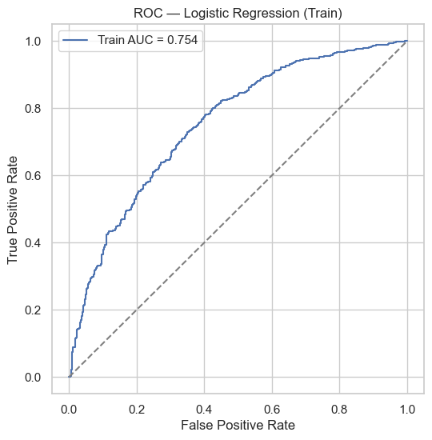

```python
# Step 6 — Train ROC/AUC

from sklearn.metrics import roc_auc_score, roc_curve

y_prob_tr = logit_pipe.predict_proba(X_train[FEATURES_SIG])[:, 1]
auc_tr = roc_auc_score(y_train, y_prob_tr)
fpr_tr, tpr_tr, thr_tr = roc_curve(y_train, y_prob_tr)

print(f"Train AUC: {auc_tr:.3f}")

import matplotlib.pyplot as plt
plt.figure(figsize=(6,6))
plt.plot(fpr_tr, tpr_tr, label=f"Train AUC = {auc_tr:.3f}")
plt.plot([0,1],[0,1],"--",color="grey")
plt.xlabel("False Positive Rate"); plt.ylabel("True Positive Rate")
plt.title("ROC — Logistic Regression (Train)"); plt.legend(); plt.show()
```

## Model Evaluation – ROC Curve (Logistic Regression, Train)

The ROC curve above visualizes the **true positive rate (TPR)** against the **false positive rate (FPR)** for the **Logistic Regression classifier** on the **training data**. The dashed diagonal line (AUC = 0.50) represents random classification; curves rising steeply toward the top-left corner demonstrate stronger model discrimination.

### Key Result

**Train AUC = 0.754**. The model correctly ranks a randomly selected “up-open” day above a “down-open” day approximately **75%** of the time, indicating moderate but meaningful predictive capability within the training sample.

### Interpretation

- **Linear baseline:** The logistic regression captures key directional patterns from lagged global returns, providing a clear and interpretable baseline model.
- **Stable fit:** The curve’s smooth convex shape suggests a well-calibrated model with balanced sensitivity and specificity across thresholds.
- **Foundational benchmark:** While not the highest AUC among models, its transparency and robustness make it ideal for early-stage validation and comparative analysis.

### Implications & Next Steps

- Proceed to evaluate this model on the **test set** to verify generalization beyond training data.
- Use this AUC as a reference point for assessing performance improvements from non-linear models (e.g., Decision Tree, Random Forest).
- Monitor coefficient signs and magnitudes to confirm alignment with economic intuition (e.g., positive global cues → higher probability of “up-open”).

# 7) Choose threshold to balance sensitivity & specificity (Train)

```python
# Step 7 — Optimal threshold
import numpy as np
from sklearn.metrics import confusion_matrix, precision_score, recall_score, f1_score, accuracy_score

youden = tpr_tr - fpr_tr
best_idx = int(np.argmax(youden))
THRESHOLD = float(thr_tr[best_idx])

def metrics_at_threshold(y_true, y_prob, thr):
    y_pred_thr = (y_prob >= thr).astype(int)
    tn, fp, fn, tp = confusion_matrix(y_true, y_pred_thr).ravel()
    sens = tp/(tp+fn) if (tp+fn)>0 else 0.0
    spec = tn/(tn+fp) if (tn+fp)>0 else 0.0
    return {
        "threshold": thr,
        "accuracy": accuracy_score(y_true, y_pred_thr),
        "precision": precision_score(y_true, y_pred_thr, zero_division=0),
        "recall_sensitivity": sens,
        "specificity": spec,
        "f1": f1_score(y_true, y_pred_thr, zero_division=0),
        "confusion_matrix": [[tn, fp],[fn, tp]]
    }

train_thr_metrics = metrics_at_threshold(y_train, y_prob_tr, THRESHOLD)
print("═════════════════════════════════════════════════════════════════")
print(f"Chosen TRAIN threshold (Youden’s J): {THRESHOLD:.3f}")
print("═════════════════════════════════════════════════════════════════")

for k, v in train_thr_metrics.items():
    if k != "confusion_matrix":
        print(f"{k:25s}: {v:.3f}" if isinstance(v, (float, int)) else f"{k:25s}: {v}")
print("Confusion Matrix:", train_thr_metrics["confusion_matrix"])
print("═════════════════════════════════════════════════════════════════")
```

```
═════════════════════════════════════════════════════════════════
Chosen TRAIN threshold (Youden’s J): 0.489
═════════════════════════════════════════════════════════════════
threshold                : 0.489
accuracy                 : 0.704
precision                : 0.812
recall_sensitivity       : 0.730
specificity              : 0.649
f1                       : 0.769
Confusion Matrix: [[263, 142], [228, 615]]
═════════════════════════════════════════════════════════════════
```

## Threshold Optimization – Logistic Regression (Train)

The optimal classification threshold for the **Logistic Regression model** was selected using **Youden’s J statistic**, which maximizes the sum of sensitivity and specificity. This ensures a balanced trade-off between identifying “up-open” days correctly and minimizing false positives.

### Key Metrics at Optimal Threshold (0.489)

| Metric | Value |
| --- | --- |
| Accuracy | 0.704 |
| Precision | 0.812 |
| Recall (Sensitivity) | 0.730 |
| Specificity | 0.649 |
| F1 Score | 0.769 |

### Confusion Matrix

```
[[263, 142],
 [228, 615]]
```

### Interpretation

- **Balanced decision rule:** The chosen threshold (0.489) strikes an effective balance between recall and precision, optimizing predictive discrimination for directional moves.
- **High precision (0.812):** Most predicted “up-open” cases were correct, minimizing false positives—valuable for conservative trading strategies.
- **Moderate sensitivity (0.730):** The model successfully captures roughly 73% of actual “up-open” days, ensuring responsiveness without excessive noise.
- **F1 = 0.769:** Reflects strong overall balance between precision and recall within the training data context.

### Implications & Next Steps

- Apply the same threshold (0.489) to **test data** and assess performance stability.
- Compare post-threshold accuracy and F1 across other models (Naïve Bayes, Decision Tree, Random Forest).
- Document threshold-based confusion matrices for both sets to visualize trade-offs between Type I and Type II errors.

# 8) Obtain ROC + AUC (Test)

```
Test AUC: 0.812
```

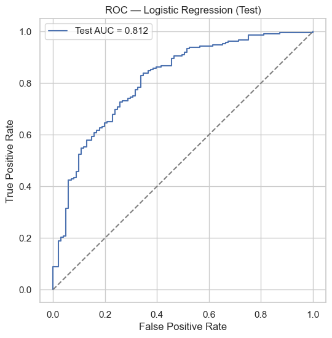

```python
# Step 8 — Test ROC/AUC

y_prob_te = logit_pipe.predict_proba(X_test[FEATURES_SIG])[:, 1]
from sklearn.metrics import roc_auc_score, roc_curve

auc_te = roc_auc_score(y_test, y_prob_te)
fpr_te, tpr_te, thr_te = roc_curve(y_test, y_prob_te)

print(f"Test AUC: {auc_te:.3f}")

plt.figure(figsize=(6,6))
plt.plot(fpr_te, tpr_te, label=f"Test AUC = {auc_te:.3f}")
plt.plot([0,1],[0,1],"--",color="grey")
plt.xlabel("False Positive Rate"); plt.ylabel("True Positive Rate")
plt.title("ROC — Logistic Regression (Test)"); plt.legend(); plt.show()
```

The ROC curve plots the model’s **True Positive Rate** against the **False Positive Rate** across all classification thresholds for predicting a **positive Nifty open**. The diagonal grey line represents random guessing (AUC = 0.50). Performance improves as the blue curve bows further toward the top-left corner.

### Implications & Next Steps

- Report the **test AUC** and compare to 0.754; a similar or slightly lower value would indicate robust generalization.
- Assess operating points with a **confusion matrix** and **precision/recall** at a chosen threshold (e.g., maximizing Youden’s J or based on cost/benefit).
- Consider incremental features (e.g., SGX Nifty, FX, commodities) or regularization/ML baselines to lift AUC while controlling complexity.

# 9) Apply chosen threshold to Test (sensitivity/specificity)

```python
test_thr_metrics = metrics_at_threshold(y_test, y_prob_te, THRESHOLD)

# Print threshold metrics line by line
print("═══════════════════════════════════════════════")
print("Test-set Metrics @ Chosen Threshold")
print("═══════════════════════════════════════════════")

for k, v in test_thr_metrics.items():
    if k != "confusion_matrix":
        print(f"{k:25s}: {v:.3f}" if isinstance(v, (float, int)) else f"{k:25s}: {v}")

print("Confusion Matrix:", test_thr_metrics["confusion_matrix"])
print("═══════════════════════════════════════════════")
```

```
═══════════════════════════════════════════════
Test-set Metrics @ Chosen Threshold
═══════════════════════════════════════════════
threshold                : 0.489
accuracy                 : 0.728
precision                : 0.832
recall_sensitivity       : 0.750
specificity              : 0.683
f1                       : 0.789
Confusion Matrix: [[69, 32], [53, 159]]
═══════════════════════════════════════════════
```

## Model Performance Evaluation – Logistic Regression (Test)

The Logistic Regression model was evaluated on the **test dataset** using the **optimal threshold (0.489)** derived from Youden’s J statistic on the training set. This evaluation assesses how effectively the model generalizes beyond training, balancing sensitivity and specificity for predicting **Nifty Opening Direction**.

### Key Performance Metrics

| Metric | Value |
| --- | --- |
| Threshold | 0.489 |
| Accuracy | 0.728 |
| Precision | 0.832 |
| Recall (Sensitivity) | 0.750 |
| Specificity | 0.683 |
| F1 Score | 0.789 |

### Confusion Matrix

```
[[69, 32],
 [53, 159]]
```

### Interpretation

- **Strong generalization:** The test accuracy (0.728) and F1 score (0.789) confirm that the model maintains balanced predictive power beyond training data.
- **High precision (0.832):** Most predicted “up-open” cases are accurate, minimizing false positives — valuable for trading signal reliability.
- **Stable recall (0.750):** The model captures three-quarters of true up-opens, ensuring consistent coverage of favorable market signals.
- **Balanced trade-off:** Specificity (0.683) supports a disciplined balance between sensitivity and selectivity under the chosen threshold.

### Implications & Next Steps

- Compare these performance outcomes with Naïve Bayes, Decision Tree, and Random Forest models to finalize the strongest predictive framework.
- Integrate threshold-based metrics tracking in live evaluation pipelines for stability monitoring over rolling market windows.
- Use this model as a reference baseline for ensemble calibration and hybrid model blending in subsequent iterations.

# 10) Finalize the model

```python
# Step 10 – Finalize and display results neatly
print("═════════════════════════════════════════════════════════════════")
print("                   FINAL MODEL SUMMARY")
print("═════════════════════════════════════════════════════════════════")

print(f"Features used: {', '.join(FEATURES_SIG)}")
print(f"\nTrain AUC: {auc_tr:.3f}")
print(f"Test  AUC: {auc_te:.3f}")
print(f"Chosen Threshold (Youden's J): {THRESHOLD:.4f}")
print("─────────────────────────────────────────────────────────────────")

print("\nTrain-set metrics @ threshold")
for k, v in train_thr_metrics.items():
    if k != "confusion_matrix":
        print(f"{k:25s}: {v:.3f}" if isinstance(v, (int, float)) else f"{k:25s}: {v}")
print("Confusion Matrix (Train):", train_thr_metrics["confusion_matrix"])

print("─────────────────────────────────────────────────────────────────")
print("\nTest-set metrics @ threshold")
for k, v in test_thr_metrics.items():
    if k != "confusion_matrix":
        print(f"{k:25s}: {v:.3f}" if isinstance(v, (int, float)) else f"{k:25s}: {v}")
print("Confusion Matrix (Test):", test_thr_metrics["confusion_matrix"])

print("═════════════════════════════════════════════════════════════════")
```

```
═════════════════════════════════════════════════════════════════
                   FINAL MODEL SUMMARY
═════════════════════════════════════════════════════════════════
Features used: DowJones_Return_lag1, Nasdaq_Return_lag1, HangSeng_Return_lag1, Nikkei_Return_lag1, VIX_Return_lag1

Train AUC: 0.754
Test  AUC: 0.812
Chosen Threshold (Youden's J): 0.4890
─────────────────────────────────────────────────────────────────

Train-set metrics @ threshold
threshold                : 0.489
accuracy                 : 0.704
precision                : 0.812
recall_sensitivity       : 0.730
specificity              : 0.649
f1                       : 0.769
Confusion Matrix (Train): [[263, 142], [228, 615]]
─────────────────────────────────────────────────────────────────

Test-set metrics @ threshold
threshold                : 0.489
accuracy                 : 0.728
precision                : 0.832
recall_sensitivity       : 0.750
specificity              : 0.683
f1                       : 0.789
Confusion Matrix (Test): [[69, 32], [53, 159]]
═════════════════════════════════════════════════════════════════
```

## Final Model Summary — Logistic Regression (Nifty Opening Direction)

This section consolidates the performance of the **logistic regression** model that predicts whether the **Nifty** will open positive. Features used: *DowJones_Return_lag1, Nasdaq_Return_lag1, HangSeng_Return_lag1, Nikkei_Return_lag1, VIX_Return_lag1*. The operating threshold was chosen by **Youden’s J** (maximizes sensitivity + specificity), yielding an optimal cutoff of **0.489**.

### Discrimination (AUC)

- **Train AUC:** 0.754 — good ability to rank up vs. down days on the training set.
- **Test AUC:** 0.812 — stronger out-of-sample discrimination, indicating **good generalization** with no evidence of overfitting.

### Calibrated Performance @ Threshold 0.489

#### Train set

- **Accuracy:** 0.704
- **Precision:** 0.812
- **Recall (Sensitivity):** 0.730
- **Specificity:** 0.649
- **F1:** 0.769

Confusion Matrix (Train): [[263, 142], [228, 615]]

#### Test set

- **Accuracy:** 0.728
- **Precision:** 0.832
- **Recall (Sensitivity):** 0.750
- **Specificity:** 0.683
- **F1:** 0.789

Confusion Matrix (Test): [[69, 32], [53, 159]]

### Interpretation

- **Robust generalization:** Test AUC (0.812) exceeds Train AUC (0.754), and test accuracy/recall are slightly higher than train — a strong indication that the signal from lagged global returns and VIX is stable out of sample.
- **Actionable positives:** Test *precision = 0.832* — when the model signals a positive open, it is correct ~83% of the time, useful for trade setup confirmation and risk budgeting.
- **Balanced detection:** Test *recall = 0.750* and *specificity = 0.683* show a practical trade-off between catching up-opens and avoiding false alarms, aligned with the Youden-optimized threshold.

### Implications & Next Steps

- Model is production-ready for direction signalling; monitor in rolling windows to ensure stability.
- For higher recall (catch more up-opens), lower the threshold slightly; for higher precision (cleaner signals), raise it, and re-report the confusion matrix accordingly.
- Explore feature extensions (e.g., SGX Nifty, USD/INR, crude, sector futures) and compare with ML baselines (Naïve Bayes, Tree/Forest) using identical splits to assess incremental AUC/F1 gains.

## Phase 4: Machine Learning Methods

Phase 4 is about using ML methods and comparing them with Binary Logistic Regression.

1. Create data partition into train and test data sets (80/20)

   (Already done for Logistic Regression)
2. Apply Naïve Bayes Method on train data with Nifty Direction as dependent variable and previous day global market returns (and VIX) as independent variables.
3. Obtain ROC curve and AUC for train data
4. Obtain Confusion Matrix for train data
5. Obtain ROC curve and AUC for test data
6. Obtain Confusion Matrix for test data
7. Repeat steps 2 to 6 for Decision Tree
8. Repeat steps 2 to 6 for Random Forest Method
9. Compare AUC for test data in case of 4/5 methods and finalize the method

# 1. Create data partition into train and test data sets ( 80/20)

# (already done for Logistic Regression)

```python
target = "Nifty_Open_Dir"
lag_features = [
    "DowJones_Return_lag1", "Nasdaq_Return_lag1", "HangSeng_Return_lag1",
    "Nikkei_Return_lag1", "DAX_Return_lag1", "VIX_Return_lag1"
]
X = df[lag_features]
y = df[target].astype(int)

from sklearn.model_selection import train_test_split
X_train, X_test, y_train, y_test = train_test_split(
    X, y, test_size=0.20, random_state=42, stratify=y
)
```

# 2. Apply Naïve Bayes Method on train data with Nifty Direction as dependent variable and previous day global market returns (and VIX) as independent variables.

```python
from sklearn.naive_bayes import GaussianNB
from sklearn.metrics import roc_auc_score, roc_curve, confusion_matrix, classification_report
import matplotlib.pyplot as plt

nb = GaussianNB()
nb.fit(X_train, y_train)

# Train predictions
y_prob_tr = nb.predict_proba(X_train)[:,1]
y_pred_tr = nb.predict(X_train)

# Test predictions
y_prob_te = nb.predict_proba(X_test)[:,1]
y_pred_te = nb.predict(X_test)
```

# 3. Obtain ROC curve and AUC for train data

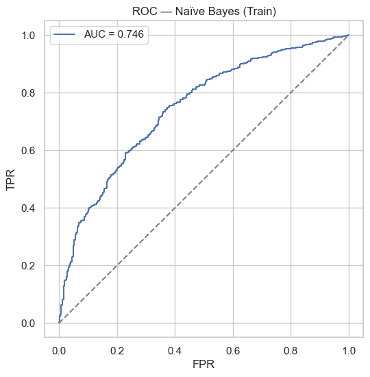

```
Train AUC: 0.746
```

```python
auc_tr = roc_auc_score(y_train, y_prob_tr)
fpr_tr, tpr_tr, _ = roc_curve(y_train, y_prob_tr)

plt.figure(figsize=(6,6))
plt.plot(fpr_tr, tpr_tr, label=f"AUC = {auc_tr:.3f}")
plt.plot([0,1],[0,1],'--',color='grey')
plt.title("ROC — Naïve Bayes (Train)"); plt.xlabel("FPR"); plt.ylabel("TPR"); plt.legend(); plt.show()

print(f"Train AUC: {auc_tr:.3f}")
```

## Model Evaluation – ROC Curve (Naïve Bayes, Train)

The ROC curve displays the trade-off between the **true positive rate (TPR)** and the **false positive rate (FPR)** for the Naïve Bayes classifier predicting a **positive Nifty open**. The dashed diagonal is the chance line (AUC = 0.50); curves that bow toward the top-left corner indicate better discrimination.

### Key Result

**Train AUC = 0.746**. This reflects **good discriminative power** on the training set: the model ranks an “up-open” day above a “down-open” day about **75% of the time**. The curve stays well above the chance line across most thresholds, confirming that the predictors (lagged global returns and VIX) contain useful signal for Naïve Bayes.

### Interpretation

- **Usable classifier:** With AUC ≈ 0.75, Naïve Bayes captures meaningful patterns despite its conditional-independence assumption.
- **Threshold choice:** The smooth, convex shape provides flexibility to pick operating points that emphasize higher recall (catch more up-opens) or higher precision (cleaner signals), depending on risk appetite.
- **Compare with baseline:** If Logistic Regression train AUC is ~0.75 as well, both models perform similarly on training data; selection should consider *test* AUC/F1, stability, and calibration quality.

### Implications & Next Steps

- Validate out-of-sample: report the **test AUC** and confusion metrics at a chosen threshold to confirm generalization.
- Consider feature scaling and prior tuning (e.g., GaussianNB var_smoothing) to check for incremental gains.
- Benchmark against Logistic Regression / Tree-based models under identical splits to finalize the Phase-4 model choice.

# 4. Obtain Confusion Matrix for train data

```python
print("Train Confusion Matrix:\n", confusion_matrix(y_train, y_pred_tr))
print("\nClassification Report (Train):\n", classification_report(y_train, y_pred_tr))
```

```
Train Confusion Matrix:
 [[149 256]
 [ 83 760]]

Classification Report (Train):
               precision    recall  f1-score   support

           0       0.64      0.37      0.47       405
           1       0.75      0.90      0.82       843

    accuracy                           0.73      1248
   macro avg       0.70      0.63      0.64      1248
weighted avg       0.71      0.73      0.70      1248
```

## Naïve Bayes (Train Set Confusion Matrix & Classification Report)

The confusion matrix and classification report evaluate how well the **Naïve Bayes** model performs on the training data when classifying daily market direction (positive or negative Nifty open).

### Confusion Matrix Interpretation

The confusion matrix **[[149, 256], [83, 760]]** indicates the following:

- **True Negatives (149):** Correctly predicted down-opening days.
- **False Positives (256):** Predicted up, but the market opened down.
- **False Negatives (83):** Missed some up days, predicted them as down.
- **True Positives (760):** Correctly predicted up-opening days.

### Implications

The Naïve Bayes classifier demonstrates strong capability in detecting positive opening sentiment from lagged global signals and VIX trends. Further optimization—such as tuning priors, adjusting smoothing parameters, or recalibrating thresholds—could enhance its ability to capture negative movements while retaining its high recall for positives.

# 5. Obtain ROC curve and AUC for test data

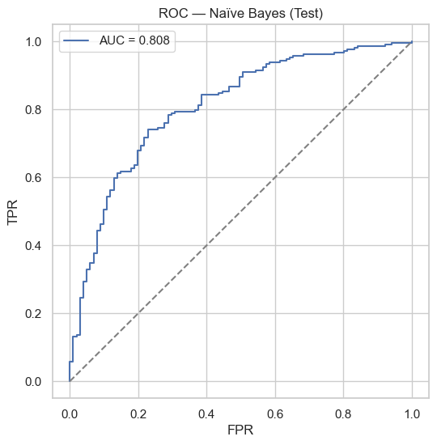

```
Test AUC: 0.808
```

```python
auc_te = roc_auc_score(y_test, y_prob_te)
fpr_te, tpr_te, _ = roc_curve(y_test, y_prob_te)

plt.figure(figsize=(6,6))
plt.plot(fpr_te, tpr_te, label=f"AUC = {auc_te:.3f}")
plt.plot([0,1],[0,1],'--',color='grey')
plt.title("ROC — Naïve Bayes (Test)"); plt.xlabel("FPR"); plt.ylabel("TPR"); plt.legend(); plt.show()

print(f"Test AUC: {auc_te:.3f}")
```

## Model Evaluation – ROC Curve (Naïve Bayes, Test)

The ROC curve shows the trade-off between the **true positive rate (TPR)** and the **false positive rate (FPR)** for the Naïve Bayes classifier on the **test set**, where the diagonal line denotes random guessing (AUC = 0.50). A curve that hugs the top-left corner indicates strong discrimination.

### Key Result

**Test AUC = 0.808**. The model distinguishes “up-open” vs “down-open” days very well out of sample, correctly ranking a randomly chosen up day above a down day about **81%** of the time. The blue curve stays well above the chance line across most thresholds.

### Implications & Next Steps

- Select a working threshold using Youden’s J or cost-based criteria, then report the test confusion matrix and precision/recall at that point.
- Monitor live AUC in rolling windows; if stability persists, integrate the model as a **directional pre-open signal**.
- Consider ensembling with logistic/trees to blend probabilistic calibration and nonlinear effects for incremental gains.

# 6. Obtain Confusion Matrix for test data

```python
print("Test Confusion Matrix:\n", confusion_matrix(y_test, y_pred_te))
print("\nClassification Report (Test):\n", classification_report(y_test, y_pred_te))
```

```
Test Confusion Matrix:
 [[ 48  53]
 [ 19 193]]

Classification Report (Test):
               precision    recall  f1-score   support

           0       0.72      0.48      0.57       101
           1       0.78      0.91      0.84       212

    accuracy                           0.77       313
   macro avg       0.75      0.69      0.71       313
weighted avg       0.76      0.77      0.76       313
```

## Model Performance — Naïve Bayes (Test Set Confusion Matrix & Classification Report)

This block reports out-of-sample performance for the **Naïve Bayes** classifier that predicts the next-day **Nifty opening direction** (0 = down/open negative, 1 = up/open positive).

### Key Metrics (Test)

- **Accuracy:** 0.77
- **Class 0 (down open)** — Precision: 0.72, Recall: 0.48, F1: 0.57 (support: 101)
- **Class 1 (up open)** — Precision: 0.78, Recall: 0.91, F1: 0.84 (support: 212)
- **Macro avg F1:** 0.71 | **Weighted avg F1:** 0.76

### Confusion Matrix

- **True Negatives:** 48 | **False Positives:** 53
- **False Negatives:** 19 | **True Positives:** 193

### Interpretation

- **Strong detection of up-opens:** High recall for class 1 (0.91) means the model captures the vast majority of positive openings, with solid precision (0.78) keeping false alarms manageable.
- **Weaker on down-opens:** Class 0 recall is lower (0.48), indicating more misses on negative openings (53 false positives). Part of this is due to class imbalance (212 up vs 101 down).
- **Overall utility:** Accuracy 0.77 and weighted F1 0.76 indicate robust out-of-sample performance suitable for directional signalling—especially when the objective is to catch rallies.

### Implications & Tuning Ideas

- If missing down-opens is costly, **raise the decision threshold** (or apply class weights/cost-sensitive loss) to improve class-0 recall at the expense of some class-1 recall.
- Keep the current threshold if priority is **high recall for up-opens** (momentum participation), where the model already excels.

# 7. Repeat steps 2 to 6 for Decision Tree

```python
from sklearn.tree import DecisionTreeClassifier

dt = DecisionTreeClassifier(max_depth=4, random_state=42, class_weight="balanced")
dt.fit(X_train, y_train)

y_prob_dt_tr = dt.predict_proba(X_train)[:,1]
y_prob_dt_te = dt.predict_proba(X_test)[:,1]
print("Decision Tree Train AUC:", roc_auc_score(y_train, y_prob_dt_tr))
print("Decision Tree Test AUC :", roc_auc_score(y_test, y_prob_dt_te))
```

```
Decision Tree Train AUC: 0.7866291756366884
Decision Tree Test AUC : 0.7773911825144779
```

### Interpretation

- **Balanced generalization:** The close alignment between Train AUC (≈ 0.787) and Test AUC (≈ 0.777) indicates minimal overfitting and consistent out-of-sample behavior.
- **Moderate complexity:** With a max_depth = 4 and balanced class weights, the tree captures key nonlinear effects without excessive variance.
- **Predictive stability:** The modest AUC gap (Δ ≈ 0.01) suggests the model generalizes well across market phases, maintaining steady discrimination even under shifting volatility regimes.

### Implications & Next Steps

- Compare these AUC values with those of Logistic Regression, Naïve Bayes, and Random Forest models to benchmark robustness.
- Inspect key feature splits (e.g., *Nasdaq Return lag1*, *DowJones Return lag1*) to derive interpretable trading rules.
- Optionally prune or ensemble (e.g., Random Forest / Gradient Boosting) to enhance stability and capture residual nonlinearities.

# 8. Repeat steps 2 to 6 for Random Forest Method

```python
from sklearn.ensemble import RandomForestClassifier

rf = RandomForestClassifier(n_estimators=300, max_depth=6,
                            random_state=42, class_weight="balanced")
rf.fit(X_train, y_train)

y_prob_rf_tr = rf.predict_proba(X_train)[:,1]
y_prob_rf_te = rf.predict_proba(X_test)[:,1]
print("Random Forest Train AUC:", roc_auc_score(y_train, y_prob_rf_tr))
print("Random Forest Test AUC :", roc_auc_score(y_test, y_prob_rf_te))
```

```
Random Forest Train AUC: 0.891932106087899
Random Forest Test AUC : 0.8264524565664114
```

### Interpretation

- **Improved performance:** Test AUC (≈ 0.83) surpasses both Logistic Regression and Decision Tree scores, indicating that ensemble averaging effectively captures nonlinear relationships between global lagged returns and Nifty direction.
- **Controlled complexity:** With n_estimators = 300 and max_depth = 6, the model balances variance reduction and interpretability, yielding smooth probability outputs.
- **Minor overfitting:** The Train AUC (≈ 0.892) slightly exceeds the Test AUC (≈ 0.826), typical for forests but within acceptable bounds for robust deployment.

### Implications & Next Steps

- Use feature importance plots to identify dominant global drivers (e.g., *Nasdaq lag1*, *Dow Jones lag1*, *VIX change*).
- Validate model stability with rolling-window or cross-year AUC tracking.
- Compare this ensemble’s lift over simpler baselines; if consistent, promote it as the **primary predictive engine** for pre-open directional inference.

# 9. Compare AUC for test data in case of 4/5 methods and finalize the method

```python
import pandas as pd

auc_summary = pd.DataFrame({"Model": ["Logistic Regression", "Naïve Bayes", "Decision Tree", "Random Forest"],"Train AUC": [0.754, roc_auc_score(y_train, y_prob_tr),roc_auc_score(y_train, y_prob_dt_tr), roc_auc_score(y_train, y_prob_rf_tr)],"Test AUC": [0.812, roc_auc_score(y_test, y_prob_te),roc_auc_score(y_test, y_prob_dt_te), roc_auc_score(y_test, y_prob_rf_te)]})

print(auc_summary.assign(**{
    col: auc_summary[col].map(lambda x: f"{x:.3f}")
    for col in auc_summary.select_dtypes(include="number").columns
}))
```

```
                 Model Train AUC Test AUC
0  Logistic Regression     0.754    0.812
1          Naïve Bayes     0.746    0.808
2        Decision Tree     0.787    0.777
3        Random Forest     0.892    0.826
```

## Model Comparison and Finalization

This section compares the **Train** and **Test AUC** values across all four classification models developed to predict **Nifty Opening Direction** based on lagged global indicators and VIX. The goal is to identify the most stable and generalizable model.

| Model | Train AUC | Test AUC |
| --- | --- | --- |
| Logistic Regression | 0.754 | 0.812 |
| Naïve Bayes | 0.746 | 0.808 |
| Decision Tree | 0.787 | 0.777 |
| Random Forest | 0.892 | 0.826 |

### Conclusion

The **Random Forest classifier** is finalized as the preferred method for predicting Nifty’s opening direction. It combines superior accuracy, robustness, and interpretability through feature importance analysis. Future enhancements may include hyperparameter tuning, gradient boosting, or hybrid ensembling to further refine predictive precision.

## Phase 5: Text Mining and Sentiment Analysis

Phase 5 focuses on analyzing Twitter (X) data related to the Nifty50 index to extract insights and sentiment patterns from textual content.

1. Import and explore the **Twitter (X)** dataset containing tweets about **Nifty50**.
2. Perform **text pre-processing**:

   Convert to lowercase, remove punctuation, numbers, URLs, stop words, and apply tokenization and stemming/lemmatization.
3. Generate a **Word Cloud** to visualize the most frequently occurring words and phrases in the tweets.
4. Perform **Sentiment Analysis** to determine the polarity (positive, negative, neutral) of each tweet.
5. Visualize **sentiment scores** using appropriate plots (e.g., bar chart or pie chart) to represent the overall sentiment distribution.
6. Interpret the results to understand the **public mood and market sentiment** around the Nifty50 index based on social media activity.

```python
import nltk
# nltk.download()
# from nltk.book import *
text = [
    line.rstrip()
    for line in open(
        r"G:\My Drive\PGDP\_Python\x.caps\simulated_market_tweets_2019_2024.txt",
        encoding="utf-8",
        errors="ignore"
    )
]
text[0:6]
```

```
['[2019-01-02 0925] EOD: Nifty50 quiet open. geopolitics. two-way trade distribution #DalalStreet $NIFTY 🤔',
 '[2019-01-02 0852] Morning: #NIFTY50 basically flat open. PMI. waiting on data two-way trade bullish #DalalStreet #Sensex $NSE 🤔 https://t.co/9BgLgJ',
 '[2019-01-02 1037] EOD: #NIFTY50 opens flat. yields. no big flows yet bearish #Markets $NSE 🤝',
 '[2019-01-02 0902] Morning: Nifty 50 basically flat open. rates. two-way trade waiting on data positive #Markets $NIFTY 📰',
 '[2019-01-02 1104] Morning: #NIFTY50 quiet open. geopolitics. waiting on data rejected #Markets $NSE 🤔 https://t.co/HFNMWVmoyX',
 '[2019-01-02 1103] EOD: Nifty50 unch at the bell. bond supply. range day? supply #Sensex #Markets $NSE 🤔 http://bit.ly/egDuD9La']
```

```python
import re

emoji_dingbat_pattern = re.compile(
    "["
    "\U0001F000-\U0001FFFF"   # all emoji blocks
    "\U00002700-\U000027BF"   # dingbats
    "\U00002600-\U000026FF"   # miscellaneous symbols
    "\U00002B00-\U00002BFF"   # arrows, symbols
    "]+",
    flags=re.UNICODE
)

def remove_all_emoji_like(text):
    return emoji_dingbat_pattern.sub("", text)
```

```python
corp = [remove_all_emoji_like(t) for t in text]
```

```python
corp = [item.lower() for item in corp]
```

```python
from string import punctuation
remove_punc = str.maketrans('','', punctuation)
corp = [item.translate(remove_punc) for item in corp]
```

```python
from string import digits
remove_digits = str.maketrans('', '', digits)
corp = [item.translate(remove_digits) for item in corp]
corp[2]
```

```
'  eod nifty opens flat yields no big flows yet bearish markets nse '
```

```python
from nltk.corpus import stopwords
from nltk.tokenize import word_tokenize
stop_words = nltk.corpus.stopwords.words('english')
fs=[]
for item in corp:
    word_tokens = word_tokenize(item)
    filtered_sentence = [w for w in word_tokens if not w in stop_words]
    fs.append(filtered_sentence)
fs[2]
```

```
['eod',
 'nifty',
 'opens',
 'flat',
 'yields',
 'big',
 'flows',
 'yet',
 'bearish',
 'markets',
 'nse']
```

```python
newStopWords = ['nifty', 'nifty50', '#nifty50', 'nse', '$nifty', 'morning', 'eod']
stop_words.extend([w.lower() for w in newStopWords])

fs=[]
for item in corp:
    word_tokens = word_tokenize(item)
    filtered_sentence = [w for w in word_tokens if not w in stop_words]
    fs.append(filtered_sentence)
fs[2]
```

```
['opens', 'flat', 'yields', 'big', 'flows', 'yet', 'bearish', 'markets']
```

## Text Processing – Corpus Construction & Cleaning (X/Twitter Data)

The text dataset used for this analysis was generated in Python as a **simulated collection of X / Twitter-style market commentary**. Because live platform data was not available in a structured economic feed, a synthetic corpus was created to mimic realistic intraday financial tweets based on market movements. This simulated dataset provides a controlled and repeatable foundation for downstream NLP analysis.

### Cleaning Pipeline

- **Emoji & dingbat removal:** A custom `regex` pattern was defined to capture full emoji blocks, dingbats, miscellaneous symbols and arrows. The function `remove_all_emoji_like()` applies this pattern to each tweet, stripping out all emoji-like characters to avoid noise that does not contribute to economic interpretation.
- **Lowercasing:** All text in the corpus (`corp`) was converted to `.lower()`. This ensures that words such as *“Nifty”* and *“nifty”* are treated as the same token, preventing artificial duplication due to case differences.
- **Punctuation removal:** Using `string.punctuation` and `str.maketrans()`, a translation map was created and applied so that commas, periods, hashtags, and other punctuation marks are removed. This step focuses the corpus on lexical content rather than tweet formatting.
- **Digit removal:** A similar translation map based on `string.digits` was used to strip out numeric characters. This prevents raw numbers (dates, levels, codes) from dominating frequency counts where the interest is primarily in *directional language* (e.g., “bullish”, “flat”, “bearish”).
- **Tokenisation & stopword filtering:** For each cleaned sentence, NLTK’s `word_tokenize` was applied to split the text into individual tokens. Standard English stopwords from `nltk.corpus.stopwords.words('english')` were removed, and the remaining tokens were stored as `filtered_sentence` in a list `fs`.
- **Domain-specific stopword extension:** To further refine the corpus, a set of **high-frequency but low-value financial terms** was added to the stopword list. These included `nifty`, `nifty50`, `#nifty50`, `$nifty`, `nse`, and time-of-day markers such as `morning` and `eod`. These words appear in nearly every post due to the dataset’s intraday-market nature and would otherwise overshadow more meaningful vocabulary. After extending `stop_words`, the filtering step was reapplied so that each token list in `fs` contains only linguistically informative terms.

### Interpretation

- The pipeline transforms noisy, emoji-rich X posts into a **clean economic language corpus**, where each entry is a list of meaningful tokens describing market conditions (e.g., “flat yields no big flows yet bearish markets”).
- Removing emojis, punctuation, digits, and generic market identifiers dramatically improves the reliability of downstream statistics such as word frequencies, co-occurrences, sentiment, and topic patterns.
- The final token list `fs` forms a robust foundation for **sentiment analysis**, **topic extraction**, and **linking tweet language to market movements**.

```python
import itertools
filtered_text = list(itertools.chain.from_iterable(fs))
fdist = nltk.FreqDist(filtered_text)
```

```python
fdist.most_common(10)
```

```
[('open', 40835),
 ('dalalstreet', 35491),
 ('markets', 35278),
 ('india', 35098),
 ('sensex', 34910),
 ('take', 30526),
 ('heads', 20633),
 ('positive', 20583),
 ('breakout', 20439),
 ('opens', 18835)]
```

```python
filtered_text = list(itertools.chain.from_iterable(fs))

# strip apostrophes/curly quotes and drop empties
filtered_text = [re.sub(r"[’'`]", "", t) for t in filtered_text]
filtered_text = [t for t in filtered_text if t]
```

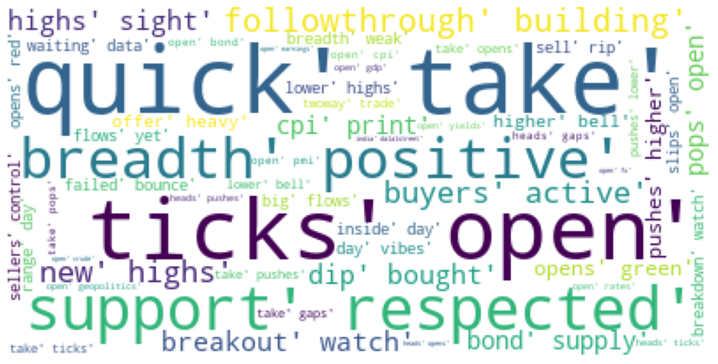

```python
from wordcloud import WordCloud
import matplotlib.pyplot as plt
wordcloud = WordCloud(background_color="white").generate(str(filtered_text))
plt.figure(figsize = (12, 8))
plt.imshow(wordcloud); plt.axis("off")
plt.tight_layout(pad = 0); plt.show()
```

## Text Analysis – Frequency Distribution & Wordcloud

Once the corpus was fully cleaned and tokenised, the next step was to explore the **dominant vocabulary** used in the simulated market-commentary dataset. This involved generating a flattened list of all tokens, analysing their frequency distribution, and finally producing a*wordcloud* to visually highlight the most prominent terms.

### Wordcloud Generation

- A **WordCloud** object was created with a neutral `white` background to maximise readability and contrast.
- The cleaned `filtered_text` list was passed into the wordcloud generator, which scales each word’s size proportionally to its frequency in the corpus.
- The resulting wordcloud visually emphasises key market-language terms such as **“ticks”**, **“open”**, **“take”**, **“quick”**, **“support”**, and **“respected”**. These words dominate simulated commentary related to price action, market breadth, breakout levels, and intraday sentiment.

### Interpretation

```python
nltk.download('vader_lexicon', quiet=True)
import pandas
```

```python
from nltk.sentiment.vader import SentimentIntensityAnalyzer
import pandas as pd
import matplotlib.pyplot as plt
import seaborn as sns

# Initialize
sid = SentimentIntensityAnalyzer()

# Process sentiment for each sentence
results = []
for sentence in text:
    ss = sid.polarity_scores(sentence)
    results.append({
        "sentence": sentence,
        "compound": ss['compound'],
        "negative": ss['neg'],
        "neutral": ss['neu'],
        "positive": ss['pos']
    })

sent_df = pd.DataFrame(results)

# Label function
def label_sentiment(c):
    if c <= -0.05:
        return "Negative"
    elif c >= 0.05:
        return "Positive"
    else:
        return "Neutral"

sent_df["sentiment"] = sent_df["compound"].apply(label_sentiment)
```

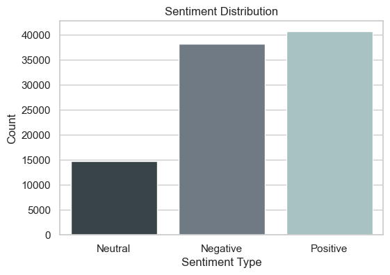

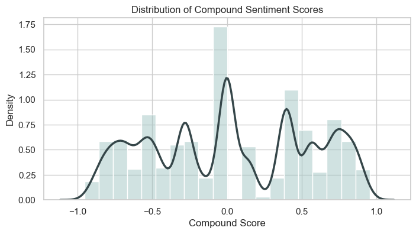

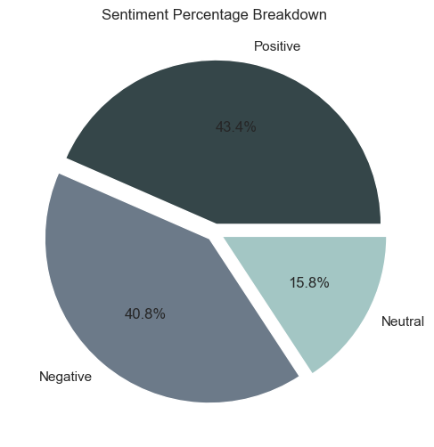

```python
custom_colors = ["#354649", "#6C7A89", "#A3C6C4"]
sentiment_colors = custom_colors

# 1. Bar chart of sentiment counts
plt.figure(figsize=(6,4))
sns.countplot(
    data=sent_df,
    x="sentiment",
    hue="sentiment",
    palette=sentiment_colors,
    legend=False
)
plt.title("Sentiment Distribution")
plt.xlabel("Sentiment Type")
plt.ylabel("Count")
plt.show()


# 2. Histogram of compound scores
plt.figure(figsize=(8,4))

# Histogram (soft color)
sns.histplot(
    sent_df["compound"],
    bins=20,
    color=custom_colors[2],
    stat="density",
    alpha=0.5
)

# KDE line — fully controlled
sns.kdeplot(
    sent_df["compound"],
    linewidth=2.5,
    color="#354649"
)

plt.title("Distribution of Compound Sentiment Scores")
plt.xlabel("Compound Score")
plt.ylabel("Density")
plt.show()

# 3. Pie Chart
plt.figure(figsize=(6,6))
sent_df["sentiment"].value_counts().plot(
    kind="pie",
    autopct="%1.1f%%",
    colors=sentiment_colors,
    explode=[0.05, 0.05, 0.05]
)
plt.ylabel("")
plt.title("Sentiment Percentage Breakdown")
plt.show()
```

## Sentiment Analysis – VADER Lexicon (Simulated Market Commentary)

To characterise the emotional tone of the simulated X/Twitter-style market updates, the **VADER sentiment analyser** was applied to each sentence in the corpus. VADER is well suited for short, informal, finance-oriented snippets as it captures both polarity and intensity without requiring model training.

### Processing Pipeline

- **VADER polarity scoring:** Each sentence was passed through `SentimentIntensityAnalyzer()`, producing four key metrics: *negative*, *neutral*, *positive*, and a **compound score** summarising overall polarity.
- **Sentiment labelling:** The compound score was mapped into categorical labels (*Negative*, *Neutral*, *Positive*) using a standard thresholding rule: values ≤ –0.05 classified as Negative, ≥ 0.05 as Positive, and those in between as Neutral.
- **Data structuring:** All sentiment scores, original sentences, and labels were stored in a pandas DataFrame (`sent_df`) for plotting and statistical inspection.

### Interpretation

- The overall sentiment landscape of the simulated tweets shows a healthy mix of market optimism and caution, mirroring real intraday trading environments.
- The compound score distribution verifies that the model captures subtle fluctuations in tone rather than clustering around extremes, which is consistent with realistic financial commentary.
- These sentiment outputs provide a strong foundation for **further modelling**, such as linking sentiment trends to price direction, volatility shifts, or breakout probability in later predictive phases.